# The Internationalization of European Financial Networks: A Quantitative Text Analysis of EU Consultation Responses

Scott James

King’s College London - scott.james@kcl.ac.uk

Stefano Pagliari

City, University of London - stefano.pagliari@city.ac.uk

Kevin L. Young

UMass Amherst - kevinlyoung@polsci.umass.edu

Abstract

Accepted for publication at the **Review of International Political Economy**

**Acknowledgments**: The authors wish to thank the three anonymous reviewers for their helpful and constructive comments. The article was presented at the ECPR Joint Sessions of Workshops in Mons, April 2019, the EUSA Biennial Conference in Denver, June 2019, and at workshops at the University of Oxford and Leiden University. We thank all the participants at these events for their comments, particularly Geoffrey Underhill, Matthias Thiemann, Greg Fuller, Natascha van der Zwan, Erik Jones, Amin Samman, and David Howarth. Finally, we are extremely grateful to Waltraud Schelkle and Dorothee Bohle for inviting us to be part of the Special Issue.

# 1 Introduction

The political power of financial firms is the subject of much scholarly research (Culpepper 2015; James 2018; Young 2015; Young and Pagliari 2017). Studies have highlighted how financial resources, technical expertise and their structural position in the economy allow financial firms and their associations to exercise significant influence over the content of financial regulatory policies (Bell and Hindmoor 2017; Howarth and Quaglia 2013; Quaglia and Spendzharova 2017). Financial actors seeking to influence the content of financial regulatory policies do not operate in a vacuum, however. Recent work has detailed how the capacity of banks to influence financial regulation and other policies is often influenced by their capacity to leverage influence by building alliances with the wider business community, and by the presence of countervailing coalitions from civil society or other actors (Chalmers 2018; James and Christopouloous 2018; Pagliari and Young 2014).

Competing theoretical perspectives have emerged within the literature to explain the development of financial lobbying networks. On the one hand, a comparative political economy (CPE) approach emphasizes how the distinct characteristics of national financial systems have translated into the emergence of distinct patterns of coordination within the financial industry, and between financial and non-financial actors (Hall and Soskice 2001; Zysman 1983). On the other hand, scholarship in the field of international political economy (IPE) claims that macro-level developments – such as the increasing internationalization of business activities – have eroded national varieties of financial systems and forced a reconfiguration of interest group activity (Mügge 2006; Farrell and Newman 2016; Newman and Posner 2018). This raises an important puzzle: which of these perspectives is best placed to explain patterns of financial industry lobbying?

Although there are numerous studies examining patterns of cooperation and conflict within the financial industry, and with the wider business community, these mostly focus on specific international or EU regulations (e.g. Fioretos 2010; Quaglia and Royo 2014), and on selected countries (e.g. Howarth and Quaglia 2013; James and Christopouloous 2018).

Our understanding of variation in national financial lobbying networks, and how they have been impacted by broader structural developments in the economy, therefore remains limited. The key empirical challenge is to find a way to reliably map patterns of financial industry coordination within and across different countries.

To address these theoretical and empirical puzzles, this article develops a new dataset and employs novel methods to systematically map financial lobbying networks. We analyse the content of more than 8,000 written responses to 66 financial policy consultations conducted by the European Commission between 2010 and 2018. Quantitative text analysis is applied to this dataset to capture two instances of coordination: 1) financial industry groups entering formal lobbying coalitions by co-signing a single regulatory consultation response; and 2) informal forms of financial industry cooperation where groups coordinate their response through the sharing or re-use of text in consultation responses.

We use this unique dataset to map domestic and international patterns of coordination by financial industry organisations at the country-level, and then statistically test the determinants of the propensity of groups to coordinate their advocacy with the financial industry. Our key findings are twofold. First, national patterns of coordination within the financial industry, and with the wider business community display significant cross-national variation. This points to the durability of distinct national-level institutional features which continue to structure patterns of financial industry lobbying. Second, we find that the internationalization in the activities of financial firms and associations is statistically associated with the formation of coordination ties with foreign financial actors. The article therefore suggests that the removal of national barriers in European financial systems has led to the emergence of a new set of cross-border alliances that overlap with – but have not necessarily undermined – domestic financial networks.

The structure of the paper is as follows. Section 2 reviews the literature on European financial systems and financial lobbying, while Section 3 outlines our data and methods. Next, the paper presents the results of the mapping exercise and descriptive analysis of financial industry coordination at the country level (Section 4), and the results of our statistical regression analysis at the actor-level (Section 5). Section 6 concludes by reflecting on the contribution to the wider political economy literature on business power, and directions for future research.

# 2 Existing Scholarship

The field of Comparative Political Economy suggests that coordination within the financial industry, and with the wider business community and public authorities, is rooted in path dependent institutional characteristics at the national level. Famously, Zysman (1983) differentiated between three main types of financial system in Europe: government-led credit-based systems (e.g. France), bank credit-based systems (e.g. Germany), and capital market-based systems (e.g. UK). In bank credit-based systems, banks represent the primary source of both short- and long-term finance to the economy; while in capital-market based systems, banks face greater competition from other financial institutions, and the issuance of debt or equity securities remain the primary source of long-term capital (Zysman 1983). While the role of the state in directly setting prices and intervening in directing the allocation of credit has largely disappeared in Europe – at the least in the way described by Zysman – the distinction between bank-based and capital market-based systems has remained durable as a way of understanding distinct ‘varieties of capitalism’ (Allen and Gale 2001; Hall and Soskice 2001).

Although this literature focuses on economic relationships, other scholars have extended these insights to the political arena, arguing that distinct financial systems generate different institutional configurations and political relationships between the state, business and finance (Story and Walter 1997). In particular, the centrality of banks as the primary source of credit is likely to produce stronger and more durable ties between the financial industry and non-financial firms in bank-based systems, as manufacturing firms have a powerful incentive to work closely with the banks in resisting regulatory initiatives that threaten to curtail this source of funding (Howarth and Quaglia 2013; Jackson and Thelen 2015). Moreover, bank-based systems have frequently given rise to extensive patterns of cross-ownership and interlocking directorates between banks and non-financial companies, which studies suggest have impacted significantly on the supply of credit and the cost of debt in countries such as Germany and Italy (Agarwal and Ann Elston 2001; di Donato and Tiscini 2009; Mizruchi 1996). By contrast, in capital market-based systems, the relationship between financial and corporate actors remains more arms-length (Deeg 1999), as banks, firms and governments operate “in distinct spheres from which they venture forth to meet as autonomous bargaining partners’ (Zysman 1983, 70). From this perspective, we would therefore expect a clear distinction to exist between systems centred around ‘the impersonal arm’s length dealings of capital markets’ and those based on ‘the personal institutional ties of banks or lending institutions’ (Hardie and Howarth 2013, 63; Zysman 1983).

The notion of durable and systematic cross-national variation in patterns of financial industry coordination has however been questioned in recent years. Deeg and Posner (2010) note that the foundation of relatively stable postwar national financial systems in Europe has been changing at an accelerating pace. For example, studies of the German financial system since the 1990s highlight the expansion of banks’ investment activities, a partial disintegration of insider-controlled corporate networks, the decline of cross-shareholdings between banks and non-financial companies, and the rise of non-banking financial institutions (Deeg and Lütz 2000; Hackethal, Schmidt, and Tyrell 2006). Some have argued that the expansion and deepening of the role of finance across industrialized economies has eroded the distinctiveness of national financial lobbying networks, and led to a reconfiguration of finance-business-state relations. In particular, the growth of bond markets, equity trading, and the importance of derivatives has reshaped bank business models in ways that question the traditional dichotomy between bank-based and capital market-based models (Hardie et al. 2013; Konings 2008).

A further challenge to national interest configurations stems from the reorganization of financial markets on a transnational basis. Studies suggest that the gradual removal of capital controls within Europe has contributed to the internationalisation of financial services (Mügge 2006) and the increasing foreign ownership of EU banks (Epstein 2017). Yet these changes have impacted on some economies more than others: while foreign ownership has remained stable in large countries such as France, Germany and UK, it has increased significantly in small, open economies such as Belgium, Ireland, and the Netherlands (Engelen and Konings 2010). Different scholars have theorized how the competitive dynamics unleashed by financial integration has threatened non-liberal forms of capitalism (Höpner and Schäfer 2010), pressuring them to restructure along Anglo-American practices (Konings 2008). It is argued that these economic transformations disrupted ties among finance, business, and the state that underpinned traditional European financial networks. For instance, German universal banks and Landesbanken bypassed national institutions to tap into global markets, with different banks selling their shares in domestic firms to pursue new opportunities abroad (Lapavitsas and Powell 2013).

Scholarship on EU lobbying suggests that these structural changes have had a significant impact in re-shaping political relationships between finance, business and the state. Empirical studies have documented how increasing economic integration has encouraged firms to increasingly bypass national governments, and to organise at the international and EU levels instead (Beyers and Kerremans 2007; Mügge 2006). Besides broadening the scope of lobbying by corporate actors, we have also seen the emergence of new coalitions within the business community. For instance, studies point to the critical role of large internationally-oriented financial institutions in lobbying around key EU regulatory initiatives, and joining transnational coalitions of financial interests, business actors, and like-minded regulators in promoting greater EU regulatory harmonization (Mügge 2013, 2006; Posner 2007).

Scholarship on how the internationalization of finance has impacted on national patterns of financial industry lobbying therefore remains highly contested. To some extent, this reflects the fact that existing studies tend to focus on providing a detailed in-depth analysis of specific regulatory case studies and/or countries. What is therefore missing is a systematic account of financial interest lobbying that maps coordination across all European countries and across a wide range of different policy issues. The next section outlines how we address this using a new dataset and text-as-data methods.

# 3 Data and Methods

## 3.1 Consultation responses to post-crisis EU regulation

To map patterns of lobbying coordination across different European countries, we build upon an established body of literature that explores the population of groups active in a given area by analysing the letters submitted in response to policy consultations. This approach has been widely used both to map interest group activities in different policy contexts (Yackee and Yackee 2006), including at the EU level (Rasmussen and Carroll 2013; Beyers et al. 2014). For example, existing studies have analysed consultation responses to map which issues different groups lobby on (Pagliari and Young 2016), the determinants of relative levels of mobilization across different stakeholders (Rasmussen and Carroll 2013), the policy positions of different groups (Chalmers 2018), and the conditions under which they are able to influence policies (Kluver 2009; Klüver and Mahoney 2015). By contrast, this study aims to analyse cross-national patterns of financial industry coordination across a broad swathe of EU financial regulation.

We draw on new data composed of the publicly-available written responses to all EU financial policy consultations launched by the European Commission between 2010 and 2018 (a full list can be found in the Appendix, Table (Table 8.1). This dataset consists of all the responses submitted by public and private actors to regulatory proposals listed under ‘Banking and Financial Services’. This comprises 66 distinct policy consultations over the period 2010-2018, which attracted a total of 8391 comment letters from financial industry groups and associations, business groups, NGOs, research institutes, trade unions, public authorities, and individuals.

After excluding all responses from individuals, we manually coded the identity of all organizational entities that responded. To do so we built upon the analysis of the population of interest groups conducted as part of the ‘Inter-Euro Project’ Research Project which maps the EU-level interest group population across different policy areas (Beyers et al. 2014). The respondents were matched with the demographic information already coded in the Inter-Euro dataset, while the groups not included were coded using the codebook developed by the Inter-Euro researchers. Moreover, in order to provide additional demographic information regarding the organization and activities of these respondents, this manual coding was supplemented by matching these respondents with their entry in the European Union Transparency (Greenwood and Dreger 2013), as well from Bureau van Dijk’s Orbis database, which contains comprehensive information over 100 million public and private companies worldwide.

Overall, we coded 6369 submitted by 1300 unique respondents. Respondents were coded based on the country in which the respondent’s headquarters are located, the type of respondent (business firms and associations, trade unions, NGOs, public authorities, etc), and the economic sector of business respondents (differentiating between financial or non-financial firms and activities). As expected, the majority of submissions come from the largest economies in Europe, namely the UK, Belgium (headquarters of most pan-European business associations), Germany and France, followed by Italy and the Netherlands. In line with the ‘business bias’ identified in the literature (Rasmussen and Carroll 2013), business groups submitted the vast majority of consultation responses, followed (by some distance) by public authorities and NGOs.[^1] A detailed breakdown of the respondents can be found in the Appendix 8.2.

## 3.2 Coordination as co-signing and text re-use

To map patterns of coordination amongst stakeholders, we analyze the content of these consultation responses. We suggest that coordination takes two main forms. The first relates to the explicit co-signing of a response letter by two or more organisations. This is a common lobbying strategy as groups can leverage their influence through formal collaboration by signalling that they have a shared policy position (Nelson and Yackee 2012). To identify these, we manually coded those instances when a response letter was co-signed by multiple groups (for a similar approach, see Box-Steffensmeier, Christenson, and Hitt 2013). In particular, co-signing could be identified in the letters sent by 326 distinct organizations (25.1 % of all respondents), for a total of 1192 cumulative ties among these groups.

This approach captures instances when groups to create a formal “lobbying coalitions” with the purpose of openly signalling to policymakers that a position has broad support among different groups (Nelson and Yackee 2012). However, not all instances of groups working together in their effort to lobby policymakers reach this level of formality and publicity. On the contrary, groups that are active in the same policy space often share information informally and form “communication networks” (Heaney 2014), without entering in a formal lobbying coalition.

In order to capture more informal types of coordination we extend our analysis beyond the list of signatories to the analysis of the content of the letters and we seek to identify instances of organisations using identical text in their responses to the same consultation (for a detailed discussion of this approach, see Pagliari and Young (2020)). Text reuse may arise because groups choose to collaborate by sharing information with one another during the consultation process, but prefer to send separate letters. It may also originate from groups copying identical text from a third source, such as the language circulated by an association of which both groups are members, an earlier consultation response, research report or policy document. In both cases, organisations do not develop their responses independently, but instead are part of the same communication network through which information is shared.

To measure this form of coordination we deploy a quantitative text analysis approach known as ‘substring matching’ (Acree et al. 2016). Similar to the software detecting plagiarism among different documents, this approach takes into account the sequencing of words in order to identify shared sequences of words across documents. In this way, the approach differ significantly from other quantitative text analysis approaches analysing the similarity of documents based on the analysis of the co-occurrence of words (so-called “bag of words” approaches), and it is better suited to identify instances when groups are actively cooperating rather than simply expressing similar policy positions (Pagliari and Young 2020).

In applying this approach to identify coordination among interest groups, we follow the steps detailed in Pagliari and Young (2020). We divide each document into separate sentences and run the Smith-Waterman algorithm between all pairwise combination of sentences from the responses to the same consultation using the ‘textreuse’ package in R (Mullen 2016).[^2] This allows us to identify multiple instances of text re-use in different and non-contiguous parts of the same documents.

The presence of text reuse between two responses to the same consultation does not always reflect coordination between groups. The first important potential source of ‘false positives’ is represented by cases when different documents cite the same publicly-available consultation documents issued by the European Commission (e.g. responses which copy and paste the question that is being addressed). To minimise these, we re-run the algorithm between the sentences identified as potential text-reuse and all the official documents published by the EU at the time of the consultation (e.g. the consultation document, plus any available translation in other languages, the press release, and any additional background documents). For each potential match, we identify the amount of text which is overlapping with a Commission document and exclude those above a certain level.[^3] The second source of false positives arises from the frequent use of ‘boilerplate language’, i.e. commonly used phrases and sentences. Building upon the approach adopted by Wilkerson, Smith, and Stramp (2015), we filter this out by removing sentences that appear repeatedly in a large number (>100) of documents.

To increase confidence that we are capturing meaningful coordination between organisations, we exclude sentences where the amount of re-used text in each sentence is limited (less than 20 consecutive words or the equivalent similarity score in the case of imperfect matches) and we only consider pairs of documents where the algorithm identifies instances of text re-use among the two responses in at least 10 separate sentences.[^4] Our data collection strategy identified 2347 cumulative ties connecting pairs of responses sharing significant amount of text, involving 499 distinct organizations (38.4 % of all respondents).

The type of coordination captured by the presence of text reuse among different responses to the same consultation differs from the type of coordination captured by different groups co-signing the same letter in important ways (see Pagliari and Young 2020). At the same time, scholars investigating coalitions among interest groups have acknowledged that both types of formal and informal alliances matter (Mahoney 2007). In the words of (Nelson and Yackee 2012), “scholars generally agree that both formal coalitions and more informal groupings are necessary to capture the construct”. As a result, as a final step, we combine instances of text re-use and co-signing to provide an overall picture of coordination between groups in their responses to EU financial regulatory consultations. We model this data as a social network where organisations (nodes) are connected if they have either submitted a co-authored response to a consultation; or they submit two separate responses which are characterized by significant text reuse. Ties are modelled as undirected because it is not possible to establish which group instigates coordination, or the direction of information flow between them, from the data.

Before analysing these results, it is important to recognize some of the limitations of this approach. First, our method cannot capture instances of surreptitious coordination: i.e. instances of groups communicating and coordinating their response, but deliberately trying to conceal this by agreeing to focus on different issues - thereby reducing the potential for text re-use or co-signing. Likewise, our approach cannot detect instances of text-reuse where an organisation has translated text from another organisation for its own use. While we recognize that this is possible, the literature suggests that groups often have an incentive to make similar or identical points in order to signal widespread support to policy makers (Nelson and Yackee 2012). Second, our approach is not able to detect instances where coordination leads to agreement to delegate responsibility for responding to a consultation to a single peak association, which speaks on behalf of multiple member organisations without these being co-signatories (Chalmers 2018). Third, by analyzing response letters to European Commission consultations, we can only observe patterns of coordination among those actors that choose to mobilize around these issues, rather than the entire population of interest groups (Berkhout et al. 2018). As a result, our approach does not allow us to capture the impact that existing communication and lobbying networks may have in facilitating the mobilization of groups in the first place.

# 4 European Financial Networks

## 4.1 Mapping coordination within European countries

In this section we disaggregate between two types of coordination: 1) ties that financial firms and associations develop with other financial and non-financial actors based in the same countries, and 2) cross-border ties that that financial firms and associations develop with financial and non-financial actors based in a different EU country. Our empirical interest in these dynamics is first and foremost descriptive in that we want to know what some of the dynamics of coalition formation actually are, and what they look like. The descriptive research question that emerges out of this is: what does coalitional ties surrounding the financial industry look like in different countries and across countries?

We begin by visualising the domestic financial lobbying networks of the four countries that account for the greatest number of responses to the consultations in our dataset (we exclude Belgium due to the presence of large numbers of pan-European associations): the UK (Figure 4.1), Germany (Figure 4.2), France (Figure 4.3), and Italy(Figure 4.4).

### UK

[interactive chart not shown]

Figure 4.1: UK Financial Network. Solid lines represent co-signing, dashed lines represent text reuse, while the thickness of the lines is weighted by the extent of coordination (i.e. the number of co-authored submissions and/or pairs of responses with text reuse). The nodes are colour coded by respondent type (blue = financial groups; green = non-financial groups; red = public authorities; white = others). The size of the node is weighted by the total number of consultation responses they submitted. Only the domestic connections between groups headquartered in the same country are visualized. In order to favour the visual comparison among the different countries, only the 50 public and private organizations who submitted most consultation responses in each country are visualized

### Germany

[interactive chart not shown]

Figure 4.2: German Financial Network. Solid lines represent co-signing, dashed lines represent text reuse, while the thickness of the lines is weighted by the extent of coordination (i.e. the number of co-authored submissions and/or pairs of responses with text reuse). The nodes are colour coded by respondent type (blue = financial groups; green = non-financial groups; red = public authorities; white = others). The size of the node is weighted by the total number of consultation responses they submitted. Only the domestic connections between groups headquartered in the same country are visualized. In order to favour the visual comparison among the different countries, only the 50 public and private organizations who submitted most consultation responses in each country are visualized

### France

[interactive chart not shown]

Figure 4.3: French Financial Network. Solid lines represent co-signing, dashed lines represent text reuse, while the thickness of the lines is weighted by the extent of coordination (i.e. the number of co-authored submissions and/or pairs of responses with text reuse). The nodes are colour coded by respondent type (blue = financial groups; green = non-financial groups; red = public authorities; white = others). The size of the node is weighted by the total number of consultation responses they submitted. Only the domestic connections between groups headquartered in the same country are visualized. In order to favour the visual comparison among the different countries, only the 50 public and private organizations who submitted most consultation responses in each country are visualized

### Italy

[interactive chart not shown]

Figure 4.4: Italian Financial Network. Solid lines represent co-signing, dashed lines represent text reuse, while the thickness of the lines is weighted by the extent of coordination (i.e. the number of co-authored submissions and/or pairs of responses with text reuse). The nodes are colour coded by respondent type (blue = financial groups; green = non-financial groups; red = public authorities; white = others). The size of the node is weighted by the total number of consultation responses they submitted. Only the domestic connections between groups headquartered in the same country are visualized. In order to favour the visual comparison among the different countries, only the 50 public and private organizations who submitted most consultation responses in each country are visualized

Each graph represents the ties between organisations headquartered in that country which lobbied most frequently on any of the financial post-crisis consultations in our dataset. In order to capture domestic ties only, we have excluded from this visualization those business associations that comprise within their membership firms located in different countries (most of which are located in Brussels). The network visualizations are suggestive of how patterns of explicit coordination (co-signing) and informal coordination (text re-use) by the financial industry vary significantly across the four countries. To analyze these patterns more systematically, and across a broader range of countries, we devise a series of descriptive statistics capturing the extent to which firms and associations within the financial industry coordinate their consultation responses with other actors from the same country (see Table 8.3 in the Appendix).

Figure 4.5 (left) measures, on the vertical axis, the intensity of lobbying by the financial industry by counting the total number of responses to any of the consultations in our dataset submitted by financial firms/associations headquartered in that country. The horizontal axis measures the percentage of these responses that have ties (i.e. demonstrate evidence of coordination through co-signing or text re-use) with other financial firms/associations based in the same country.

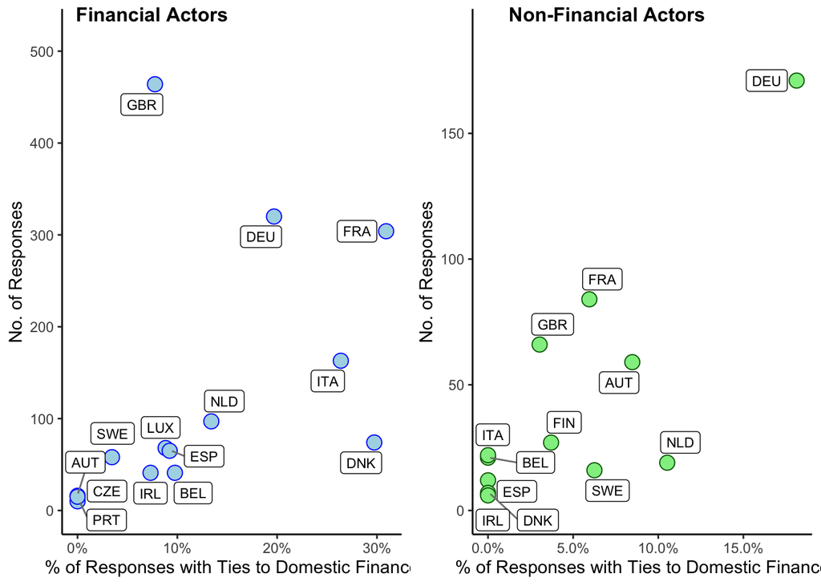

Figure 4.5: Domestic coordination with financial firms and association from the same country

At one end of the spectrum, Britain stands out for the extent of mobilization by financial industry actors. The number of responses to the consultation from financial actors based in the UK (464) is significantly higher than in France (304) and Germany (320). At the same time, the mobilization of the British financial industry displays significantly lower levels of internal coordination compared to their counterparts in similarly-sized economies. In particular, the main association representing the British banking industry during this period (British Banking Association) is less connected with major UK banks and other financial associations than it is the case for other peak banking association in other countries.

At the opposite end of the spectrum, France displays the highest percentage of consultation responses from the financial industry that are coordinated with other financial firms and associations in the same country (31%, compared to 8% of UK financial responses, 20% of German financial responses, and 26% of Italian financial responses). This level of coordination is particularly pronounced among the main financial associations and major banks, such as BNP Paribas and Société Générale, who coordinate their responses repeatedly over different consultations. The network comprised by the main Italian financial firms and associations demonstrates a similar level of internal coordination as France, as the main Italian financial industry associations regularly co-sign their responses to EU consultations, as well as frequently coordinate with large banks, such as Unicredit and Intesa. Among the large economies, Germany represents an intermediate case in terms of the propensity of German financial firms and associations to work together. While German financial associations have in different circumstances co-authored or coordinated their responses, major German banks such as Deutsche Bank or market financial infrastructure firms such as Deutsche Börse rarely join these efforts.

The graph on the right side of Figure 4.5 extends the analysis to the relationship between finance and the wider business community. On the vertical axis it maps the intensity of the lobbying by non-financial actors over EU financial policies, by counting the total number of non-financial firms and associations that submitted responses to any of the consultations in our dataset. The horizontal axis measures the percentage of these responses that are coordinated with financial firms and associations from the same country. At a glance, this enables us to compare the extent of coordination between the wider business community and the financial industry across multiple countries.

For both of these measures described above, Germany stands out as an outlier. The number of non-financial firms/associations mobilizing in Germany (59 actors sending 171 responses) is more than twice the numbers found in the UK (18 actors sending 66 responses) and in France (26 actors sending 84 responses). Not only is the mobilization of the non-financial community far more extensive in Germany than in any other European country, but it is also more highly coordinated with the domestic financial industry. In particular 18.1% of all the responses from German non-financial firms and associations over EU financial policies are coordinated with financial firms and associations. This is a significantly higher percentage than that found in France (6%), Italy (0%), and Britain (3%). Closer analysis reveals that coordination among financial and non-financial actors in Germany is particularly developed among some of the main peak business associations which have strong and durable ties to a large number of German financial associations and firms. While the level of coordination between non-financial and financial actors in France is significantly lower overall, it is noteworthy how frequently the main peak business association (MEDEF) coordinated its response with the main financial associations. This contrasts with other large economies, such as the UK or Italy, where the main peak business associations (Confederation of British Industry, Confindustria) were less engaged in EU financial policymaking, and where no coordination with the financial industry was detected.

Overall, this analysis provides support for the notion that significant differences continue to persistent in the configuration of interests found around financial policies in different EU countries. These variations are broadly consistent with the expectations from the comparative political economy literature reviewed above, especially when it comes to the largest economies. In particular, the UK consistently displays lower levels of coordination within the financial industry and between finance and the rest of the business community compared to major continental economies.

## 4.2 Mapping coordination across European countries

The next stage is to map the extent to which financial industry groups coordinate their lobbying activity with actors based in other countries. Figure 4.6 visualises the extent of coordination between financial firms and associations headquartered in different EU member states, with the thickness of the line denoting the level of co-signing and text reuse across submissions from groups based in different countries.

Unlike the previous section, here we also include ties with international associations headquartered in another country. As a result, the central location of Belgium in the transnational European financial network is not surprising, given that Brussels hosts the majority of the main pan-European trade associations. The centrality of these actors in the European network is demonstrated by the fact that financial actors located in Belgium represent the most important international counterparts for financial firms and associations based in around two-thirds of the other European countries.

[interactive chart not shown]

Figure 4.6: Network of ties across EU countries

The network visualization suggests that the initiatives taken by businesses headquartered in the largest European countries to lobby the European Union are highly interconnected with one another. It is also notable that important regional clusters exist. A regional coordination cluster can be found for example across Scandinavian and Baltic countries, while a second one links Central and Eastern European countries together. Geographical proximity, and enduring political, economic and cultural ties between these countries remain an important driver of cross-border coordination by financial firms and associations when responding to EU consultations.

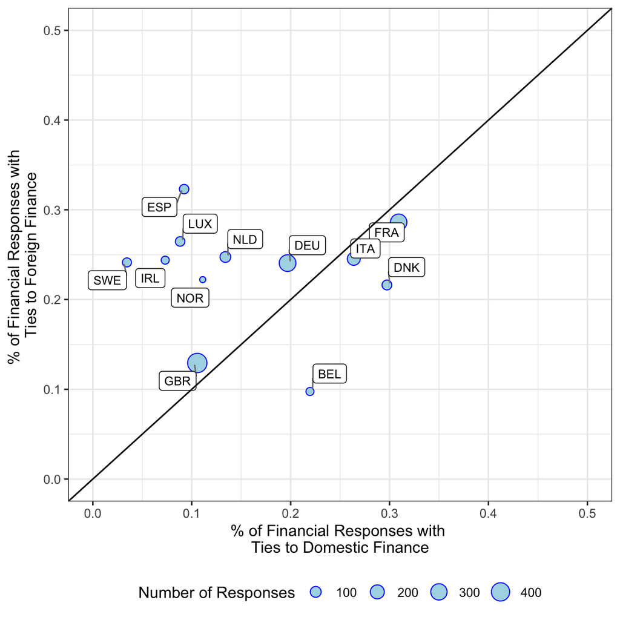

Figure 4.7: Domestic vs. International Ties among the Responses from Financial Firms and Associations

When we focus on the largest economies in the EU, it is notable how significant differences emerge regarding the level of cross-border coordination. Significantly, financial organisations based in the UK are overall less likely to coordinate across borders (36% of financial actors) than their continental European counterparts in countries such as Italy (62.1), Spain (50%), France (49%) and Germany (44.1) (see Table 8.3 in the Appendix). Overall, the figure highlights how in the four largest economies, the degree of domestic coordination within the financial industry is generally correlated with the level of coordination with foreign counterparts. These results are consistent with the notion that the same country-level characteristics that sustain different levels of domestic coordination also influence the likelihood that the same actors will coordinate internationally.

A closer look also reveals how these cross-country variations in the level of international coordination tend to become less pronounced when we focus on those actors that lobby most frequently - namely, the largest financial associations and firms. In particular all of financial groups that engage regularly in the EU policy process (>10 responses) in France (vs. 49% of all the financial groups) and in Italy (vs. 62.1% of all the financial groups), and a vast majority of these groups in Germany (76.9% vs. 44.1% of all the financial groups) and the (78.6% vs. 36% of all the financial groups) coordinated their responses with a foreign counterpart. The highly internationalised character of lobbying by the most active financial firms and associations echoes the findings of multiple studies showing that large financial groups have increasingly re-oriented their lobbying activity to the transnational level since the crisis, and seek to build durable alliances to influence international and EU regulation (Farrell and Newman 2014; Newman and Posner 2018).

# 5 Internationalization of Financial Network

## 5.1 Analysis

The previous section has illustrated the main differences in the level of domestic and international coordination found in different countries. While this analysis has illustrated that clear national differences persist in the level of domestic and cross-border coordination found around the financial industry, a closer look has also revealed how important differences remain within these countries.

In the final part of our analysis, we seek to probe further the determinants of financial industry coordination in Europe by moving from country-level to actor-level measures. In particular, building upon the literature reviewed above, we posit two hypotheses regarding the consequences of the internationalization in the activities of financial and other actors over the formation of lobbying coordination ties. First, we posit those actors whose activities are not confined to a national context are more likely to build ties with foreign actors (H1). Second, we posit that internationalization of market activities lead these actors to abandon domestic coalitions and therefore decreases ties with domestic actors (H2).

If both H1 and H2 are supported, we could conclude that the greater cross-border integration of European markets is producing new alliances that are replacing or disrupting domestic configurations of financial interests. If H1 is supported but not H2, then the implication would be that internationalization is leading to a new layer of cross-border alliances that complements existing domestic coalitions in finance. If H2 is supported but not H1, then the implication would be that while internationalization is eroding domestic lobbying coalitions, it is not driving the formation of new international alliances.

We use statistical regression analysis, whereby the dependent variable is the number of times a given organisational actor has engaged in coordination with other financial groups in its response to a financial consultation. We include three different versions of the dependent variable: one measuring total coordination ties, and account of this for domestic-only and foreign-only ties. Because coordination is infrequent across all actors, there are a large number of zeros in the dependent variable, necessitating the use of a negative binomial regression model (rather than a normal linear regression).

We are interested in identifying what individual characteristics of the groups that engage in the EU policy process correlate with the presence of ties with finance. In order to evaluate whether the greater internationalization of financial activities has influenced the patterns of coordination, we include the variable ‘International Actor’, which is coded as 1 when the scope of the activities undertaken by a respondent is coded as either ‘European Union’ or ‘Non-European Multinational’ in the INTEREURO dataset, and coded as 0 when the entity is organized at the “sub-national” or “national” level. In addition, we also devise an additional measure of the level of internationalization in the activities of financial and non-financial firms by extracting information regarding the number of subsidiaries each respondent has in a country that is different from the one of the headquarter. This information was available only for a subset of the firms in our dataset. If the internationalization of finance has generated new alliances that deviate from the national financial patterns of coordination, we should find a positive association between these variables and foreign coordination ties, but not with domestic coordination ties.

A wide range of control variables are deployed in order to appropriately condition the main association we are interested in. The variable ‘Business Association’, ‘Firm’ and ‘Professional Association’ are used because these categories may be associated with different levels of coordination by virtue of the organizational nature of the respondent. For example, associations may have more links than firms because they are more likely to be tied to other organizations. The variable ‘Financial Actor’ is included to wash out the effect of financial actors connecting with other financial actors, which is obviously much more likely than financial actors connecting with non-financial actors.

In order to explore to what extent patterns of coordination with the financial industry are driven by the geographical location where groups operate, we include a variable related to whether an organization was located in a financial center, based on the designation in the Global Financial Center Index. Moreover, given the importance of Brussels as a hub for lobbying and sharing of information (Sorurbakhsh 2016), we included variables related to whether they had an office in Brussels. We also include a control variable for the ‘propensity to coordinate’ with non-financial actors. This is important to include since we want to establish the propensity of coordinating with financial actors specifically, and not the propensity to coordinate with other actors in general. We also include the variable ‘Lobbying Propensity’, a measure of the number of total letters a group sent across all the EU consultations in our sample over the period of analysis.[^5]

In addition to these actor-level variables, we condition on the different country-level attributes, based on a range of conditions considered important in studies of comparative political economy. For example, the literature on interest intermediation has theorized how the incentives that firms have to organise collectively varies across different types of interest intermediation (Eising 2009; Kohler-Koch and Eising 1999; Schmidt 2002). While in pluralist systems interests are more likely to be fragmented (Siaroff 1999), in neo-corporatist systems, firms are more likely to coordinate their lobbying (Hanegraaff and Pritoni 2019). The ‘Corporatism’ variable captures these country-level differences and is taken from the measures developed in (Jahn 2016). We also included a variable which is intended to condition our results on the relative importance of the banking system in a national economy (Allen and Gale 2001). Our ‘Banking Credit’ variable takes the domestic credit to the private sector from the banks as a proportion of domestic credit from the entire financial system, and is thus expressed as a ratio, at the country level.[^6]

A “Financialization” variable captures the structural importance of the financial industry in the economy. Financialization has been measured in a number of different ways in extant literature (see Engelen and Konings 2010; Krippner 2011; Lapavitsas and Powell 2013; Maxfield, Winecoff, and Young 2017). The inclusion of this variable is to control for the claim in the literature related to the fact that financialization has expanded the number of public and private actors supporting pro-finance policies and generated new coalitions (see Callaghan 2015; Young and Pagliari 2017). We elected to use data from the OECD Structural Analysis of National Economies (STAN) dataset, which provide comparable international data on the sectoral composition of OECD countries over time.[^7] More specifically we used a measure of the value-added of the financial sector as a component of value added for all sectors and industries (for a similar approach, see Witko 2016).[^8] There may be measurement error in this simple country-level financialization indicator (see Christophers 2015); at the same time there are no country-level alternatives that cover our range of countries. Our measures of production-based ratios and value-added based ratios are by no means comprehensive indicators of the phenomena in question, but they are consistent with the many interventions within the literature emphasizing that financial sector prominence is associated with monopoly profits or rent (Christophers 2018; Jadayev and Epstein 2007; Tomaskovic-Devey and Lin 2011).[^9] Summary statistics for the variables included in our analysis are presented in Table 8.7 in the Appendix.

## 5.2 Results

Table 5.1 illustrates the results of our regression analysis, which should be read in a comparative way across models, as we vary the measurement of the dependent variable in each case. Model 1 has total coordination ties as the dependent variable, and finds no statistically significant association with the international actor variable and this outcome after conditioning on the range of factors described above. The same is the case for Model 2, which includes a modified control variable for propensity to coordinate with domestic non-financial actors. In Model 3, we find a positive and statistically significant association for the international actor variable on the outcome of foreign coordination ties. These comparative results across Models 1-3, suggests support for the notion that the internationalization in the activities of a group is associated with the emergence of cross-border ties (H1), but not for the notion that more internationalized actors are less likely to cooperate with other domestic groups (H2).

We then implemented two alternative modelling choices to assess the robustness of the positive support for the internationalization hypothesis. First, we considered whether the results in Models 2 and 3 are driven by imbalance in the covariates. To assess this possibility, we used coarsened exact matching (Iacus, King, and Porro 2012) to balance all covariates across treatment (international actor) and non-treatment (not international actor) groups. We then re-ran Models 2 and 3 in Models 2b and 3b, with the appropriate importance re-weightings and found we could not discount the statistical significance of the international actor variable. In fact, it increased in statistical significance and the size of the coefficient estimate increased. This suggests that that the effect may be underestimated in the original Model 3.

Second, we sought to understand whether a completely different measure of internationalization would still yield the same results. Thus, in Models 4 and 5 we repeat the analytical comparison between domestic and international ties but instead use number of subsidiaries abroad as the indicator of actor-level internationalization. This reduces the number of observations significantly, and eliminates several of the actor-level variables given the fact that all observations in Models 4 and 5 are firms. We are able to use an additional variable derived from the Transparency Register to control for resources on full-time equivalent staff lobbying the European Union, which does not reduce the number of observations (but does do so in the earlier models, and dramatically so; hence we excluded it). In Models 4 and 5 we find that the Number of Subsidiaries Abroad variable is statistically significant in Model 5 (foreign ties) but not in Model 4 (domestic ties).

Table 5.1: Regression Table

| Variable | (1) Total Coordination Ties | (2) Domestic Coordination Ties | (3) Foreign Coordination Ties | (2b) Domestic Coordination Ties | (3b) Foreign Coordination Ties | (4) Domestic Coordination Ties | (5) Foreign Coordination Ties |
| --- | --- | --- | --- | --- | --- | --- | --- |
| International Actor | 0.11 (0.15) | -0.27 (0.19) | 0.33** (0.17) | 0.15 (0.27) | 0.91*** (0.32) |  |  |
| Bank Credit Proportion | -0.96* (0.54) | -2.91*** (0.7) | 0.3 (0.61) | -0.05 (1.06) | 1.15 (1.21) | -0.81 (1.11) | -1.68 (1.02) |
| Financialization (VA) | -2.91* (1.63) | -6.04** (2.61) | -0.46 (1.94) | -8.09** (4.08) | 4.14 (3.17) | -13.88 (8.82) | 1.15 (3.82) |
| Corporatism | 0.14* (0.07) | 0 (0.09) | 0.17** (0.08) | 0.21 (0.15) | 0.02 (0.17) | 0.15 (0.16) | 0.32** (0.16) |
| Business Association | 1.19*** (0.3) | 1.42*** (0.38) | 0.92** (0.37) | 1.96*** (0.72) | 0.04 (0.97) |  |  |
| Firm | 1.02*** (0.31) | 0.97** (0.41) | 0.95** (0.37) | 1.54** (0.71) | 0.51 (0.93) |  |  |
| Professional Association | 1.54** (0.74) | 0.86 (0.96) | 1.63** (0.77) | 1.69 (1.06) | 2.49* (1.27) |  |  |
| Financial Actor | 1.80*** (0.17) | 1.78*** (0.23) | 1.97*** (0.18) | 0.90** (0.37) | 2.92*** (0.4) | 3.59*** (0.79) | 1.57*** (0.43) |
| Has office in a financial center | -0.18 (0.17) | -0.13 (0.19) | -0.16 (0.18) | -0.21 (0.31) | -0.57 (0.39) | -0.60** (0.29) | -0.31 (0.23) |
| Has office in Brussels | 0.42*** (0.15) | -0.12 (0.19) | 0.68*** (0.17) | 0.26 (0.69) | 1.91*** (0.56) | 0.03 (0.36) | -0.03 (0.3) |
| Lobbying Propensity | 0.11*** (0.01) | 0.11*** (0.01) | 0.10*** (0.01) | 0.20*** (0.06) | 0.19*** (0.06) | 0.10*** (0.02) | 0.12*** (0.02) |
| Propensity to coordinate (non-financial partners)) | 0.04*** (0.01) |  |  |  |  |  |  |
| Propensity to coordinate with domestic non-financial groups |  | 0.36*** (0.06) |  |  |  | 0.31*** (0.1) |  |
| Propensity to coordinate with foreign non-financial groups |  |  | 0.05*** (0.02) | 0.02 (0.05) | 0.13 (0.1) |  | 0.35*** (0.07) |
| Subsidaries Abroad |  |  |  |  |  | 0.1 (0.07) | 0.12** (0.05) |
| EU Lobbying Personnel |  |  |  |  |  | 0.1 (0.1) | 0.02 (0.07) |
| Constant | -1.73*** (0.5) | -1.22** (0.6) | -3.28*** (0.57) | -3.59*** (0.97) | -5.39*** (1.27) | -3.29*** (1.07) | -1.02 (0.82) |
| lnalpha | 1.05*** (0.09) | 1.27*** (0.11) | 1.12*** (0.11) | 0.96* (0.52) | 1.87*** (0.19) | 0.04 (0.34) | 0.17 (0.27) |
| Observations | 1078 | 1078 | 1078 | 527 | 527 | 160 | 160 |
| Pseudo R2 | 0.127 | 0.154 | 0.136 | 0.091 | 0.097 | 0.255 | 0.163 |
| BIC | 3264.2 | 2070.92 | 2587.94 | 697.05 | 776.17 | 331.41 | 524.18 |

Note:  
Robust standard errors in parentheses, * p < 0.10, ** p < 0.05, *** p < 0.01

These results indicate a regularity consistent with H1 but not H2 – i.e. higher internationalization of financial actors is associated with more cross-border alliances, but not at the expense of domestic coordination. Figure 5.1 below visualizes our findings for the two key internationalization variables across Models 1-5, and helps to highlight the comparative dimension of our analysis by visualizing how the two different international actor variables have coefficients and 90% confidence intervals above the zero coefficients line in Models 3, 3b and 5 only, where the dependent variable is international ties only. The other models, shown on the top panel, all cross the zero coefficients line.

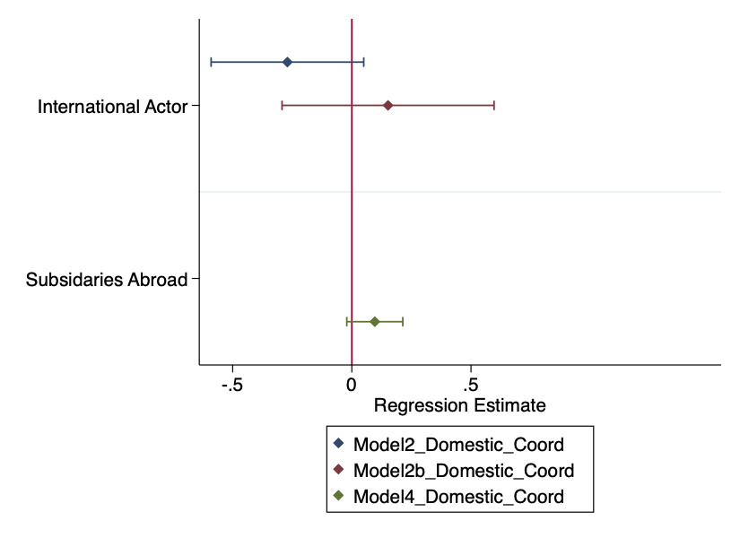

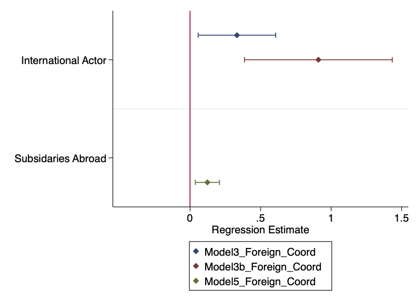

Figure 5.1: Coefficients Plot of Internationalization variables in Models 1-5;  
Left = Domestic Ties as the Dependent Variable  
Right = Foreign Ties as the Dependent Variable

We re-ran the above Models 1-5 again but changed the dependent variable to a binary indicator and used logistic regression. The results, reported in Table 8.8 in the Appendix, are the same with respect to the internationalization indicators for Models 3b, 4 and 5 (Model 2b did not converge). The fact that these statistical associations persist after a range of relevant controls are used and after we measure internationalized activities in different ways suggests to us that the scope of the activities by firms and associations remains an important predictor of whether these will join forces with financial actors located in other jurisdictions. Nevertheless, we endeavored to find ways in which the internationalization finding may be conditional on other factors described in the literature. Given that the research on coordination ties of the kind we are exploring here is still new, we found guidance from three literatures in particular.

First, we ran these regressions again using a country-level internationalization indicator,[^10] which was not significant while the actor-level internationalization variables remained so, suggesting to us that it is not the country-level environments that drive actor-level behaviour but rather actor-level attributes, consistent with some other recent scholarship (Maxfield, Winecoff, and Young 2017).[^11] Second, the financialization literature discussed above suggests a variant in which individual firms are financialized, rather than entire (country-level) economies, and thus we gathered data on the percentage of subsidiaries of a firm that were financial in nature, using data from Orbis. We included variables for firm-level financialization in the form of the percentage of financial subsidiaries. This meant sub-setting the data for non-financial firms only (since measuring the financialization of financial firms is somewhat tautological). Third, a rich literature on inter-firm coordination and political action suggests that there may be a role for inter-corporate personnel networks in affecting coordination (Carroll and Sapinski 2010; Chalmers and Young 2020; Murray 2017). From Orbis we collected information regarding the individuals that occupy senior management roles or sit in the Board of the companies in our dataset, and matched them with the list of individuals occupying these roles in the European financial institutions in order to identify corporate interlocks. We incorporated information on elite ties by counting the percentage of ties that a given firm had to foreign firms. Applying these methods dramatically reduce the number of observations (to 67) and thus we urge caution in their interpretation. Yet we did find some evidence that firm-level financialization may contribute to foreign coordination ties. More importantly, across two out of three models the internationalization patterns described above persist under these revised models. The exception is one model in which we include ties to foreign firms. Each of these models, 6-8, is reported in Appendix Table 8.9.

# 6 Conclusion

This article set out to analyse systematically patterns of financial industry lobbying within and across different European countries for the first time. We developed a novel dataset to capture the extent to which financial organisations coordinated their lobbying with other financial and non-financial organisations in response to EU regulatory consultations, both domestically and internationally. Specifically, we use text analysis to: 1) measure co-signing and text re-use in consultation responses as evidence of formal and informal forms of coordination among groups in lobbying the EU policymaking process; 2) map domestic and international patterns of coordination by financial industry organisations at the country-level; and 3) statistically test the relationship between the internationalization of financial organisations and patterns of cross-border coordination at the actor-level.

The findings make two main contributions to political economy scholarship on business power (Lindblom 1977; Swank 1992; Culpepper 2015). First, mapping the scale and scope of hitherto hidden forms of coordination reveals more subtle forms of financial industry influence which is arguably not adequately captured by traditional categories of ‘structural power’ (i.e. the dependency of the state on business for growth and investment) and ‘instrumental power’ (i.e. lobbying resources, revolving doors, etc) (Culpepper 2015). For example, analysis of text re-use networks contributes to a growing body of scholarship on the ‘relational’ or ‘network’ power of finance (see Knaack 2018; Pagliari and Young 2014; Winecoff 2015). In particular, mapping lobbying coordination systematically in this way potentially enables us to identify those powerful financial groups that control information flows, broker relationships and/or coordinate industry-wide responses, based on their centrality (i.e. interconnectedness) within national or transnational text re-use networks. In addition, the capacity of firms to coordinate their communications also provides important new evidence of the ‘structural-informational’ power of finance (see Bernhagen 2007; James 2018). This refers to the fact that lobbying is a necessary but insufficient condition for influence: policy makers must also be persuaded that the information transmitted about the impact of regulatory change is credible. The ability to signal credibility through the careful coordination of consultation responses to ensure consistency and clarity alerts us to an underappreciated and understudied source of financial power.

Second, the article sheds new light on how financial power is mediated by domestic institutions. Our analysis shows how patterns of lobbying continue to be shaped by national structures of interest intermediation, which accords with recent work highlighting the critical role of institutions and ideas in constraining business power (Bell and Hindmoor 2015). It also points to the existence of distinct national ‘varieties’ of business power, characterised by variation in the extent to which financial industry influence is leveraged through organisational networks (as in coordinated market economies), rather than individual firm-level attributes (e.g. liberal market economies). We suggest that studies of financial lobbying would therefore benefit from a closer dialogue with the comparative capitalism literature as a means of further unpacking the national context-specific characteristics of financial power.

Finally, the article also makes a broader contribution to scholarship on the political economy of Europe. Importantly, we find that durable patterns of national-level lobbying are overlaid by extensive transnational alliances. Hence, the regression analysis confirms that actor-level internationalization is associated with the formation of greater ties with foreign financial firms, but is not associated with less ties to domestic groups. This is supportive of the argument that the removal of national barriers between European financial systems has led to the formation of a new layer of cross-border alliances (Beyers and Kerremans 2007; Mügge 2006). Crucially, however, our research suggests that these new transnational ties complement – but do not necessarily substitute for – existing domestic financial interest coalitions. This is important because it suggests that EU financial integration may support or even reinforce – rather than challenge – national-level diversity in lobbing networks (Ruigrok and van Tulder 1996; Weiss 2003). In conclusion, the article demonstrates how key insights from both comparative and international political economy scholarship can be integrated to capture the important dynamics of continuity and change unleashed by European integration.

We suggest two main directions for further research, both designed to address the limitations of this study. First, while the analysis in this paper has investigated the patterns of coordination in the post-crisis period, the diversity of regulatory initiatives during this period did not allow us to investigate change in the level of coordination across time. Further work might expand the analysis beyond the limited period investigated in this paper and explore how and why coordination within and across different countries varies across time. This would be better placed to detect longer-term macro-level developments and how these have shaped financial industry lobbying strategies. Second, our analysis focuses on countries within the EU, which may potentially serve as a source of bias in the results. We would fully expect trends towards internationalisation to be particularly pronounced in the context of European financial market integration. Future research would do well to test the hypotheses, and to apply the novel methods developed here, to a wider range of non-EU countries to investigate how robust our results are. The principal challenge of doing so, however, is to find meaningfully comparable data on industry responses to regulatory consultations.

# 7 Bibliography

Acree, Brice, Eric Hansen, Joshua Jansa, and Kelsey Shoub. 2016. “Comparing and Evaluating Cosine Similarity Scores, Weighted Cosine Similarity Scores, & Substring Matching.”

Agarwal, Rajshree, and Julie Ann Elston. 2001. “BankFirm Relationships, Financing and Firm Performance in Germany.” *Economics Letters* 72 (2): 225–32. https://doi.org/10.1016/S0165-1765(01)00427-X.

Allen, Franklin, and Douglas Gale. 2001. *Comparing Financial Systems*. Cambridge, MA: MIT Press.

Bell, Stephen, and Andrew Hindmoor. 2015. “Taming the City? Ideas, Structural Power and the Evolution of British Banking Policy Amidst the Great Financial Meltdown.” *New Political Economy* 20 (3): 454–74. https://doi.org/10.1080/13563467.2014.951426.

———. 2017. “Structural Power and the Politics of Bank Capital Regulation in the United Kingdom.” *Political Studies* 65 (1): 103–21. https://doi.org/10.1177/0032321716629479.

Berkhout, Joost, Jan Beyers, Caelesta Braun, Marcel Hanegraaff, and David Lowery. 2018. “Making Inference Across Mobilisation and Influence Research: Comparing Top-down and Bottom-up Mapping of Interest Systems.” *Political Studies* 66 (1): 43–62. https://doi.org/10.1177/0032321717702400.

Bernhagen, Patrick. 2007. *The Political Power of Business: Structure and Information in Public Policymaking*. Routledge Research in Comparative Politics 21. London ; New York: Routledge.

Beyers, Jan, Laura Chaqués Bonafont, Andreas Dür, Rainer Eising, Danica Fink-Hafner, David Lowery, Christine Mahoney, William Maloney, and Daniel Naurin. 2014. “The INTEREURO Project: Logic and Structure.” *Interest Groups & Advocacy* 3 (2): 126–40. https://doi.org/10.1057/iga.2014.8.

Beyers, Jan, and Bart Kerremans. 2007. “Critical Resource Dependencies and the Europeanization of Domestic Interest Groups.” *Journal of European Public Policy* 14 (3): 460–81. https://doi.org/10.1080/13501760701243822.

Box-Steffensmeier, Janet M., Dino P. Christenson, and Matthew P. Hitt. 2013. “Quality over Quantity: Amici Influence and Judicial Decision Making.” *American Political Science Review* 107 (3): 446–60. https://doi.org/10.1017/S000305541300021X.

Boyer, Robert. 1996. *States Against Markets: The Limits of Globalization*. First. Routledge. https://doi.org/10.4324/9780203982846.

Callaghan, H. 2015. “Who Cares About Financialization? Self-Reinforcing Feedback, Issue Salience, and Increasing Acquiescence to Market-Enabling Takeover Rules.” *Socio-Economic Review* 13 (2): 331–50. https://doi.org/10.1093/ser/mwu037.

Carroll, William K., and Jean Philippe Sapinski. 2010. “The Global Corporate Elite and the Transnational Policy-Planning Network, 1996-2006. A Structural Analysis.” *International Sociology* 25 (4): 501–38. https://doi.org/10.1177/0268580909351326.

Cerny, Philip. 2010. *Rethinking World Politics: A Theory of Transnational Neopluralism*. New York, NY: Oxford University Press.

CGFS. 2018. “Structural Changes in Banking After the Crisis.” CGFS Papers No 60. Basel: Committee on the Global Financial System.

Chalmers, Adam W. 2018. “Unity and Conflict: Explaining Financial Industry Lobbying Success in European Union Public Consultations: Financial Industry Lobbying.” *Regulation & Governance*, November. https://doi.org/10.1111/rego.12231.

Chalmers, Adam William, and Kevin L Young. 2020. “Network Effects in the Formation of the Financial Industry’s Regulatory Preferences in the European Union.” *Business and Politics* 22 (1): 52–84. https://doi.org/10.1017/bap.2019.33.

Christophers, Brett. 2015. “The Limits to Financialization.” *Dialogues in Human Geography* 5 (2): 183–200.

———. 2018. “Financialisation as Monopoly Profit: The Case of US Banking.” *Antipode* 50 (4): 864–90. https://doi.org/10.1111/anti.12383.

Culpepper, Pepper D. 2015. “Structural Power and Political Science in the Post-Crisis Era.” *Business and Politics* 17 (03): 391–409. https://doi.org/10.1515/bap-2015-0031.

Deeg, Richard. 1999. *Finance Capitalism Unveiled: Banks and the German Political Economy*. University of Michigan Press.

Deeg, Richard, and Susanne Lütz. 2000. “Internationalization and Financial Federalism.” *Comparative Political Studies* 33 (3): 374–405. https://doi.org/10.1177/0010414000033003004.

Deeg, Richard, and Elliot Posner. 2010. “Institutional Change in Financial Systems.” In *The Oxford Handbook of Comparative Institutional Analysis*, edited by Glenn Morgan, John L. Campbell, Colin Crouch, Ove Kaj Pedersen, and Richard Whitley, First. Oxford University Press. https://doi.org/10.1093/oxfordhb/9780199233762.001.0001.

di Donato, Francesca, and Riccardo Tiscini. 2009. “Cross Ownership and Interlocking Directorates Between Banks and Listed Firms: An Empirical Analysis of the Effects of Debt Leverage and Costs in the Italian Case.” *Corporate Ownership and Control* 6 (3). https://doi.org/10.22495/cocv6i3c4p6.

Eising, Rainer. 2009. *The Political Economy of State-Business Relations in Europe: Interest Mediation, Capitalism and EU Policy Making*. London: Routledge.

Engelen, Ewald, and Martijn Konings. 2010. “Financial Capitalism Resurgent: Comparative Institutionalism and the Challenges of Financialization.” In *The Oxford Handbook of Comparative Institutional Analysis*, edited by Glenn Morgan, John L. Campbell, Colin Crouch, Ove Kaj Pedersen, and Richard Whitley. Oxford: Oxford University Press. https://doi.org/10.1093/oxfordhb/9780199233762.003.0022.

Epstein, Rachel. 2017. *Banking on Markets: The Transformation of Bank-State Ties in Europe and Beyond*. Oxford: Oxford University Press.

Farrell, Henry, and Abraham Newman. 2015. “The New Politics of Interdependence.” *Comparative Political Studies* 48 (4): 497–526. https://doi.org/10.1177/0010414014542330.

———. 2016. “The New Interdependence Approach: Theoretical Development and Empirical Demonstration.” *Review of International Political Economy* 23 (5): 713–36. https://doi.org/10.1080/09692290.2016.1247009.

Farrell, Henry, and Abraham L. Newman. 2014. “Domestic Institutions Beyond the Nation-State: Charting the New Interdependence Approach.” *World Politics* 66 (02): 331–63. https://doi.org/10.1017/S0043887114000057.

Fioretos, Orfeo. 2010. “Capitalist Diversity and the International Regulation of Hedge Funds.” *Review of International Political Economy* 17 (4): 696–723.

Greenwood, Justin, and Joanna Dreger. 2013. “The Transparency Register: A European Vanguard of Strong Lobby Regulation?” *Interest Groups & Advocacy* 2 (2): 139–62. https://doi.org/10.1057/iga.2013.3.

Hackethal, Andreas, Reinhard H. Schmidt, and Marcel Tyrell. 2006. “The transformation of the German financial system.” *Revue d’economie Politique* Vol. 116 (4): 431–56.

Hall, Peter, and David Soskice. 2001. “Varieties of Capitalism: The Institutional Foundations of Comparative Advantage.”

Hanegraaff, Marcel, and Andrea Pritoni. 2019. “United in Fear: Interest Group Coalition Formation as a Weapon of the Weak?” *European Union Politics*, February, 1465116518824022. https://doi.org/10.1177/1465116518824022.

Hardie, Iain, and David Howarth. 2013. *Market-Based Banking and the International Financial Crisis*. Oxford: Oxford University Press.

Hardie, Iain, David Howarth, Sylvia Maxfield, and Amy Verdun. 2013. “Banks and the False Dichotomy in the Comparative Political Economy of Finance.” *World Politics* 65 (04): 691–728. https://doi.org/10.1017/S0043887113000221.

Heaney, Michael T. 2014. “Multiplex Networks and Interest Group Influence Reputation: An Exponential Random Graph Model.” *Social Networks* 36 (January): 66–81. https://doi.org/10.1016/j.socnet.2012.11.003.

Hirst, Paul Q., and Grahame Thompson. 1999. *Globalization in Question: The International Economy and the Possibilities of Governance*. 2nd ed. Cambridge, UK ; Malden, MA: Polity.

Howarth, David J., and Lucia Quaglia. 2016. *The Political Economy of European Banking Union*. First edition. Oxford, United Kingdom: Oxford University Press.

Howarth, David, and Lucia Quaglia. 2013. “Banking on Stability: The Political Economy of New Capital Requirements in the European Union.” *Journal of European Integration* 35 (3): 333–46. https://doi.org/10.1080/07036337.2013.774780.

———. 2018. “Brexit and the Battle for Financial Services.” *Journal of European Public Policy* 25 (8): 1118–36. https://doi.org/10.1080/13501763.2018.1467950.

Höpner, Martin, and Armin Schäfer. 2010. “A New Phase of European Integration: Organised Capitalisms in Post-Ricardian Europe.” *West European Politics* 33 (2): 344–68. https://doi.org/10.1080/01402380903538997.

Iacus, Stefano M., Gary King, and Giuseppe Porro. 2012. “Causal Inference Without Balance Checking: Coarsened Exact Matching.” *Political Analysis* 20 (1): 1–24. https://doi.org/10.1093/pan/mpr013.

Jackson, Gregory, and Kathleen Thelen. 2015. “Stability and Change in CMEs: Corporate Governance and Industrial Relations in Germany and Denmark.” In *The Politics of Advanced Capitalism*, edited by Pablo Beramendi, Silja Hausermann, Herbert Kitschelt, and Hanspeter Kriesi, 305–30. Cambridge: Cambridge University Press. https://doi.org/10.1017/CBO9781316163245.013.

Jadayev, Arjun, and Gerald Epstein. 2007. “The Correlates of Rentier Returns in OECD Countries.” *Political Economy Research Institute (PERI) Working Paper* 123.

Jahn, Detlef. 2016. “Changing of the Guard: Trends in Corporatist Arrangements in 42 Highly Industrialized Societies from 1960 to 2010.” *Socio-Economic Review* 14 (1): 47–71. https://doi.org/10.1093/ser/mwu028.

James, Scott. 2018. “The Structural-Informational Power of Business: Credibility, Signalling and the UK Banking Reform Process.” *Journal of European Public Policy* 25 (11): 1629–47. https://doi.org/10.1080/13501763.2017.1349166.

James, Scott, and Dimitries Christopouloous. 2018. “Reputational Leadership and Preference Similarity: Explaining Organisational Collaboration in Bank Policy Networks.” *European Journal of Political Research* 57 (2): 518–38. https://doi.org/10.1111/1475-6765.12237.

Kluver, Heike. 2009. “Measuring Interest Group Influence Using Quantitative Text Analysis.” *European Union Politics* 10 (4): 535–49. https://doi.org/10.1177/1465116509346782.

Klüver, Heike, and Christine Mahoney. 2015. “Measuring Interest Group Framing Strategies in Public Policy Debates.” *Journal of Public Policy* 35 (2): 223–44. https://doi.org/10.1017/S0143814X14000294.

Knaack, Peter. 2018. *A Web Without a Center*. Vol. 1. Oxford University Press. https://doi.org/10.1093/oso/9780190864576.003.0009.

Kohler-Koch, Beate, and Rainer Eising. 1999. *The Transformation Governance in the European Union*. London: Routledge.

Konings, Martijn. 2008. “European Finance in the American Mirror: Financial Change and the Reconfiguration of Competitiveness.” *Contemporary Politics* 14 (3): 253–75. https://doi.org/10.1080/13569770802396311.

Krippner, Greta R. 2011. *Capitalizing on Crisis: The Political Origins of the Rise of Finance*. Cambridge, MA: Harvard University Press.

Lapavitsas, C., and J. Powell. 2013. “Financialisation Varied: A Comparative Analysis of Advanced Economies.” *Cambridge Journal of Regions, Economy and Society* 6 (3): 359–79. https://doi.org/10.1093/cjres/rst019.

Lindblom, Charles E. 1977. *Politics and Markets : The World’s Political and Economic Systems*. New York: Basic Books.

Linder, Fridolin, Bruce Desmarais, Matthew Burgess, and Eugenia Giraudy. 2018. “Text as Policy: Measuring Policy Similarity Through Bill Text Reuse.” *Policy Studies Journal*, October. https://doi.org/10.1111/psj.12257.

Mahoney, Christine. 2007. “Networking Vs. Allying: The Decision of Interest Groups to Join Coalitions in the US and the EU.” *Journal of European Public Policy* 14 (3): 366–83. https://doi.org/10.1080/13501760701243764.

Maxfield, Sylvia, W. Kindred Winecoff, and Kevin L. Young. 2017. “An Empirical Investigation of the Financialization Convergence Hypothesis.” *Review of International Political Economy* 24 (6): 1004–29. https://doi.org/10.1080/09692290.2017.1371061.

Mizruchi, Mark S. 1996. “What Do Interlocks Do? An Analysis, Critique, and Assessment of Research on Interlocking Directorates.” *Annual Review of Sociology* 22 (1996): 271–98. https://doi.org/10.1146/annurev.soc.22.1.271.

Mullen, Lincoln. 2016. “Textreuse: Detect Text Reuse and Document Similarity.” *R Package Version 0.1.4*.

Murray, Joshua. 2017. “Interlock Globally, Act Domestically: Corporate Political Unity in the 21st Century.” *American Journal of Sociology* 122 (6): 1617–63. https://doi.org/10.1086/691603.

Mügge, Daniel. 2006. “Reordering the Marketplace: Competition Politics in European Finance.” *Journal of Common Market Studies* 44 (5): 991–1022.

———. 2013. “The Political Economy of Europeanized Financial Regulation.” *Journal of European Public Policy*, no. April: 37–41.

Nelson, David, and Susan Webb Yackee. 2012. “Lobbying Coalitions and Government Policy Change: An Analysis of Federal Agency Rulemaking.” *The Journal of Politics* 74 (2): 339–53. https://doi.org/10.1017/S0022381611001599.

Newman, Abraham, and Elliot Posner. 2018. *Voluntary Disruptions: International Soft Law, Finance, and Power*. First edition. Transformations in Governance. Oxford, United Kingdom: Oxford University Press.

Pagliari, Stefano, and Kevin Young. 2020. “Exploring Information Exchange Among Interest Groups: A Text-Reuse Approach.” *Working Paper* Available at http://www.stefanopagliari.net/pdf/Pagliari_Young_Exploring_Information_Exchange_Text_Reuse.html.

———. 2014. “Leveraged Interests: Financial Industry Power and the Role of Private Sector Coalitions.” *Review of International Political Economy* 21 (3): 575–610. https://doi.org/10.1080/09692290.2013.819811.

———. 2016. “The Interest Ecology of Financial Regulation: Interest Group Plurality in the Design of Financial Regulatory Policies.” *Socio-Economic Review* 14 (2): 309–37. https://doi.org/10.1093/ser/mwv024.

Posner, Elliot. 2007. “Financial Transformation in the European Union.” In *Making History: European Integration and Institutional Change at Fifty*, edited by Sophie Meunier and Kathleen McNamara. Oxford: Oxford University Press.

Quaglia, Lucia, and Sebastián Royo. 2014. “Banks and the Political Economy of the Sovereign Debt Crisis in Italy and Spain.” *Review of International Political Economy* 0 (0): 1–23. https://doi.org/10.1080/09692290.2013.877059.

Quaglia, Lucia, and Aneta Spendzharova. 2017. “The Conundrum of Solving ‘Too Big to Fail’ in the European Union: Supranationalization at Different Speeds: Solving ‘Too Big to Fail’ in the EU.” *JCMS: Journal of Common Market Studies* 55 (5): 1110–26. https://doi.org/10.1111/jcms.12531.

Rasmussen, Anne, and Brendan J. Carroll. 2013. “Determinants of Upper-Class Dominance in the Heavenly Chorus: Lessons from European Union Online Consultations.” *British Journal of Political Science* 44 (02): 445–59. https://doi.org/10.1017/S0007123412000750.

Ruigrok, Winfried, and Rob van Tulder. 1996. *The Logic of International Restructuring: The Management of Dependencies in Rival Industrial Complexes*. First. Routledge. https://doi.org/10.4324/9781315004198.

Schmidt, Vivien. 2002. *The Futures of European Capitalism*. Oxford: Oxford University Press. https://doi.org/10.13140/RG.2.1.2488.6883.

Siaroff, Alan. 1999. “Corporatism in 24 Industrial Democracies: Meaning and Measurement.” *European Journal of Political Research* 36 (2): 175–205. https://doi.org/10.1111/1475-6765.00467.

Smith, Temple F, and Michael S Waterman. 1981. “Identification of Common Molecular Subsequences.” *Journal of Molecular Biology* 147 (1): 195–97.

Sorurbakhsh, Laila. 2016. “Interest Group Coalitions and Lobbying Environments: Toward a New Theoretical Perspective.” *Interest Groups & Advocacy* 5 (3): 200–223. https://doi.org/10.1057/s41309-016-0003-8.

Story, Jonathan, and Ingo Walter. 1997. *Political Economy of Financial Integration in Europe: The Battle of the System*. Manchester: Manchester University Press.

Swank, Duane. 1992. “Politics and the Structural Dependence of the State in Democratic Capitalist Nations.” *American Political Science Review* 86 (1): 38–54. https://doi.org/10.2307/1964014.

Tomaskovic-Devey, D., and K.-H. Lin. 2011. “Income Dynamics, Economic Rents, and the Financialization of the U.S. Economy.” *American Sociological Review* 76 (4): 538–59. https://doi.org/10.1177/0003122411414827.

Weiss, Linda, ed. 2003. *States in the Global Economy: Bringing Domestic Institutions Back In*. First. Cambridge University Press. https://doi.org/10.1017/CBO9780511491757.

Wilkerson, John, David Smith, and Nicholas Stramp. 2015. “Tracing the Flow of Policy Ideas in Legislatures: A Text Reuse Approach.” *American Journal of Political Science* 59 (4): 943–56. https://doi.org/10.1111/ajps.12175.

Winecoff, William Kindred. 2015. “Structural Power and the Global Financial Crisis: A Network Analytical Approach.” *Business and Politics* 17 (03): 495–525. https://doi.org/10.1515/bap-2014-0050.

Witko, Christopher. 2016. “The Politics of Financialization in the United States, 19492005.” *British Journal of Political Science* 46 (02): 349–70. https://doi.org/10.1017/S0007123414000325.

Yackee, Jason Webb, and Susan Webb Yackee. 2006. “A Bias Towards Business? Assessing Interest Group Influence on the U.S. Bureaucracy.” *The Journal of Politics* 68 (01): 128–39. https://doi.org/10.1111/j.1468-2508.2006.00375.x.

Young, Kevin. 2015. “Not by Structure Alone: Power, Prominence, and Agency in American Finance.” *Business and Politics* 17 (03): 443–72. https://doi.org/10.1515/bap-2015-0004.

Young, Kevin, and Stefano Pagliari. 2017. “Capital United? Business Unity in Regulatory Politics and the Special Place of Finance.” *Regulation & Governance* 11 (1): 3–23. https://doi.org/10.1111/rego.12098.

Zysman, John. 1983. *Governments, Markets and Growth: Finance and the Politics of Industrial Change*. Ithaca, NY: Cornell University Press.

# 8 Appendix

## 8.1 Policy Consultations

Table 8.1: EU Commission policy consultations

| Title | Launch Date | N. Responses | URL |
| --- | --- | --- | --- |
| Fitness check on supervisory reporting (deadline extended) | 01/12/2017 | 152 | https://ec.europa.eu/info/consultations/finance-2017-supervisory-reporting-requirements_en |
| Statutory prudential backstops addressing insufficient provisioning for newly originated loans that turn non-performing (targeted consultation) | 10/11/2017 | 26 | https://ec.europa.eu/info/consultations/finance-2017-non-performing-loans-backstops_en |
| Institutional investors and asset managers’ duties regarding sustainability | 13/11/2017 | 158 | https://ec.europa.eu/info/consultations/finance-2017-investors-duties-sustainability_en |
| Finalisation of Basel III (targeted consultation) | 16/03/2018 | 50 | https://ec.europa.eu/info/consultations/finance-2018-basel-3-finalisation_en |
| Building a proportionate regulatory environment to support SME listing | 18/12/2017 | 59 | https://ec.europa.eu/info/consultations/finance-2017-barriers-listing-smes_en |
| Post-trade in a Capital Market Union: dismantling barriers and strategy for the future | 23/08/2017 | 55 | https://ec.europa.eu/info/consultations/finance-2017-post-trade_en |
| Transparency and fees in cross-border transactions in the EU | 24/07/2017 | 90 | https://ec.europa.eu/info/consultations/finance-2017-cross-border-transactions-fees_en |
| Prevention and amicable resolution of disputes between investors and public authorities within the single market (deadline extended) | 31/07/2017 | 17 | https://ec.europa.eu/info/consultations/finance-2017-investment-protection-mediation_en |
| Development of secondary markets for non-performing loans and distressed assets and protection of secured creditors from borrowers’ default | 10/07/2017 | 53 | https://ec.europa.eu/info/consultations/finance-2017-non-performing-loans_en |
| Conflict of laws rules for third party effects of transactions in securities and claims | 07/04/2017 | 32 | https://ec.europa.eu/info/consultations/finance-2017-securities-and-claims_en |
| FinTech: a more competitive and innovative European financial sector | 23/03/2017 | 200 | https://ec.europa.eu/info/consultations/public-consultation-fintech-more-competitive-and-innovative-european-financial-sector_en |
| Operations of the European Supervisory Authorities | 21/03/2017 | 212 | https://ec.europa.eu/info/consultations/public-consultation-operations-european-supervisory-authorities_en |
| Capital markets union mid-term review 2017 | 20/01/2017 | 197 | https://ec.europa.eu/info/consultations/public-consultation-capital-markets-union-mid-term-review-2017_en |
| Capital markets union: action on a potential EU personal pension framework | 27/07/2016 | 63 | http://ec.europa.eu/finance/consultations/2016/personal-pension-framework/index_en.htm |
| Review of the EU Macro-prudential policy framework | 01/08/2016 | 76 | http://ec.europa.eu/finance/consultations/2016/macroprudential-framework/index_en.htm |
| Main barriers to the cross–borders distribution of investment funds across the EU | 02/06/2016 | 49 | http://ec.europa.eu/finance/consultations/2016/cross-borders-investment-funds/index_en.htm |
| Evaluation of the financial conglomerate directive | 09/06/2016 | 25 | http://ec.europa.eu/finance/consultations/2016/financial-conglomerates-directive/index_en.htm |
| Non-binding guidelines on methodology for reporting non-financial information | 15/01/2016 | 274 | http://ec.europa.eu/finance/consultations/2016/non-financial-reporting-guidelines/index_en.htm |
| Green Paper on retail financial services: better products, more choice, and greater opportunities for consumers and businesses | 10/12/2015 | 330 | http://ec.europa.eu/finance/consultations/2015/retail-financial-services/index_en.htm |
| Call for evidence: EU regulatory framework for financial services | 30/09/2015 | 264 | http://ec.europa.eu/finance/consultations/2015/financial-regulatory-framework-review/index_en.htm |
| Review of the European Venture Capital Funds (EuVECA) and European Social Entrepreneurship Funds (EuSEF) regulations | 30/09/2015 | 45 | http://ec.europa.eu/finance/consultations/2015/venture-capital-funds/index_en.htm |
| Covered bonds in the European Union | 30/09/2015 | 72 | http://ec.europa.eu/finance/consultations/2015/covered-bonds/index_en.htm |
| Possible impact of the CRR and CRD IV on bank financing of the economy | 15/07/2015 | 84 | http://ec.europa.eu/finance/consultations/2015/long-term-finance/index_en.htm |
| Public consultation on further corporate tax transparency | 17/06/2015 | 301 | http://ec.europa.eu/finance/consultations/2015/further-corporate-tax-transparency/index_en.htm |
| Regulation (EU) No 648/2012 on OTC derivatives, central counterparties and trade repositories | 21/05/2015 | 171 | http://ec.europa.eu/finance/consultations/2015/emir-revision/index_en.htm |
| An EU framework for simple, transparent and standardised securitisation | 18/02/2015 | 121 | http://ec.europa.eu/finance/consultations/2015/securitisation/index_en.htm |
| Review of the Prospectus Directive | 18/02/2015 | 157 | http://ec.europa.eu/finance/consultations/2015/prospectus-directive/index_en.htm |
| Building a Capital Markets Union | 18/02/2015 | 413 | http://ec.europa.eu/finance/consultations/2015/capital-markets-union/index_en.htm |
| Potential economic consequences of country-by-country reporting under Directive 2013/36/EU | 11/07/2014 | 8 | http://ec.europa.eu/finance/consultations/2014/country-by-country-crd4/index_en.htm |
| Review of the European System of Financial Supervision | 26/04/2013 | 92 | http://ec.europa.eu/finance/consultations/2013/esfs/index_en.htm |
| Insurance of Natural and Man-made Disasters | 16/04/2013 | 74 | http://ec.europa.eu/finance/consultations/2013/disasters-insurance/index_en.htm |
| Structural Reform of the Banking Sector | 16/05/2013 | 111 | http://ec.europa.eu/finance/consultations/2013/banking-structural-reform/index_en.htm |
| Long-term financing of the European economy | 25/03/2013 | 349 | http://ec.europa.eu/finance/consultations/2013/long-term-financing/index_en.htm |
| Possible framework for the recovery and resolution of nonbank financial institutions | 05/10/2012 | 73 | http://ec.europa.eu/finance/consultations/2012/nonbanks/index_en.htm |
| Regulation of indices | 05/09/2012 | 80 | http://ec.europa.eu/finance/consultations/2012/benchmarks/index_en.htm |
| Recommendations of the High-level Expert Group on Reforming the structure of the EU banking sector | 02/10/2012 | 95 | http://ec.europa.eu/finance/consultations/2012/hleg-banking/index_en.htm |
| Shadow banking | 19/03/2012 | 149 | http://ec.europa.eu/finance/consultations/2012/shadow/index_en.htm |
| Bank accounts | 20/03/2012 | 129 | http://ec.europa.eu/finance/consultations/2012/bank-accounts/index_en.htm |
| Reforming the structure of the EU banking sector | 03/05/2012 | 76 | http://ec.europa.eu/finance/consultations/2012/banking-sector/index_en.htm |
| Towards an integrated European market for card, internet and mobile payments | 11/01/2012 | 315 | http://ec.europa.eu/finance/consultations/2012/card-internet-mobile-payments/index_en.htm |
| Application of Directive 2007/44 EC as regards acquisitions and increase of holdings in the financial sector | 08/12/2011 | 10 | http://ec.europa.eu/finance/consultations/2011/acquisitions/index_en.htm |
| Promoting Social Investment Funds as part of the Social Business Initiative | 13/07/2011 | 68 | http://ec.europa.eu/finance/consultations/2011/social-investment-funds/index_en.htm |
| New European regime for venture capital | 15/06/2011 | 50 | http://ec.europa.eu/finance/consultations/2011/venture-capital/index_en.htm |
| Possible measures to strengthen bank capital requirements for counterparty credit risk | 09/02/2011 | 41 | http://ec.europa.eu/finance/consultations/2011/credit-risk/index_en.htm |
| Study on interest rate restrictions | 25/01/2011 | 57 | http://ec.europa.eu/finance/consultations/2011/interest-rate-restrictions/index_en.htm |
| Central securities depositories (CSDs) and on the harmonisation of certain aspects of securities settlement in the European Union | 13/01/2011 | 107 | http://ec.europa.eu/finance/consultations/2011/csd/index_en.htm |
| Technical details of a possible european crisis management framework | 06/01/2011 | 159 | http://ec.europa.eu/finance/consultations/2011/crisis-management/index_en.htm |
| Legislative changes to the UCITS depositary function and to the UCITS managers remuneration | 14/12/2010 | 63 | http://ec.europa.eu/finance/consultations/2010/ucits/index_en.htm |
| Review of the Markets in Financial Instruments Directive (MiFID) | 08/12/2010 | 388 | http://ec.europa.eu/finance/consultations/2010/mifid/index_en.htm |
| Reinforcing national sanctioning regimes in the financial sector | 08/12/2010 | 67 | http://ec.europa.eu/finance/consultations/2010/sanctions/index_en.htm |
| Consultation on legislative steps for the Packaged Retail Investment Products initiative | 26/11/2010 | 143 | http://ec.europa.eu/finance/consultations/2010/prips/index_en.htm |
| Review of the Insurance Mediation Directive (IMD) | 26/11/2010 | 129 | http://ec.europa.eu/finance/consultations/2010/insurance-mediation/index_en.htm |
| Central securities depositories (solvency-2s) and on the harmonisation of certain aspects of securities settlement in the European Union | 24/11/2010 | 88 | http://ec.europa.eu/finance/consultations/2010/solvency-2/index_en.htm |
| Disclosure of non-financial information by companies | 22/11/2010 | 365 | http://ec.europa.eu/finance/consultations/2010/non-financial-reporting/index_en.htm |
| Harmonisation of securities law | 05/11/2010 | 151 | http://ec.europa.eu/finance/consultations/2010/securities/index_en.htm |
| Credit Rating Agencies (CRAs), new initiatives | 05/11/2010 | 96 | http://ec.europa.eu/finance/consultations/2010/cra/index_en.htm |
| Financial Reporting on a Country-by-Country Basis by Multinational Companies | 26/10/2010 | 97 | http://ec.europa.eu/finance/consultations/2010/financial-reporting/index_en.htm |
| Countercyclical buffers | 22/10/2010 | 54 | http://ec.europa.eu/finance/consultations/2010/capital-buffer/index_en.htm |
| Access to a basic payment account | 06/10/2010 | 78 | http://ec.europa.eu/finance/consultations/2010/payment-account/index_en.htm |
| White Paper on insurance guarantee schemes | 12/07/2010 | 76 | http://ec.europa.eu/finance/consultations/2010/whitepaper-on-igs/index_en.htm |
| Review of the market abuse directive | 28/06/2010 | 91 | http://ec.europa.eu/finance/consultations/2010/mad/index_en.htm |
| Short selling | 14/06/2010 | 122 | http://ec.europa.eu/finance/consultations/2010/short-selling/index_en.htm |
| Derivatives and market infrastructures | 14/06/2010 | 225 | http://ec.europa.eu/finance/consultations/2010/derivatives/index_en.htm |
| Study on tying and other potentially unfair commercial practices in the retail financial service sector | 15/01/2010 | 66 | http://ec.europa.eu/finance/consultations/2010/tying/index_en.htm |

## 8.2 Demographic characteristics of respondents

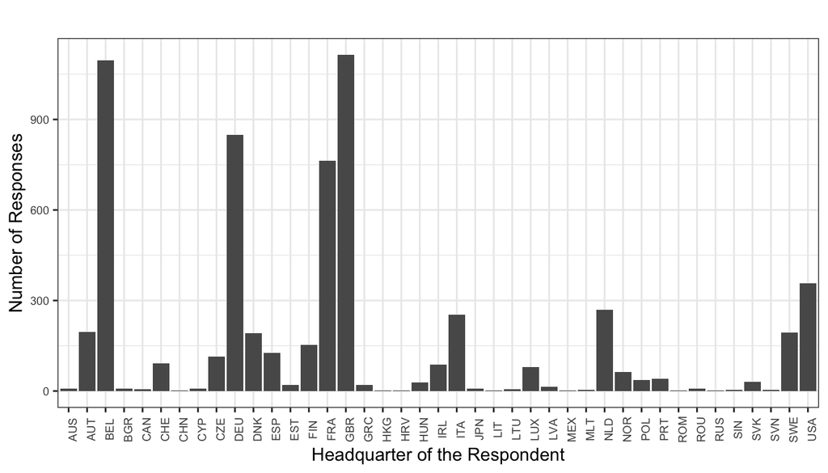

Figure 8.1: Responses to Consultation by Country of Origin of the Respondent

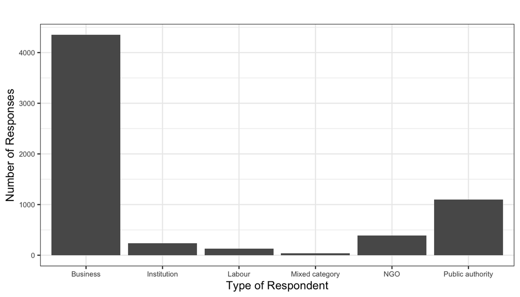

Figure 8.2: Responses to Consultation by Type of Respondent

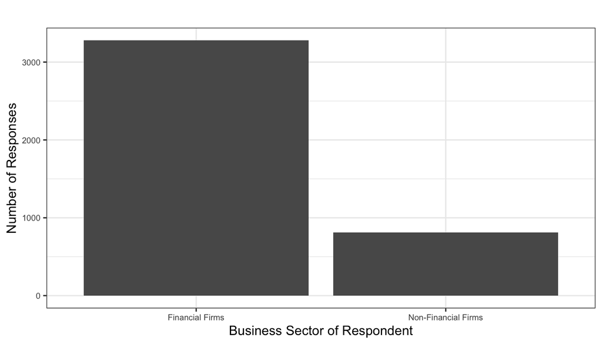

Figure 8.3: Responses to Consultation by Business Sector

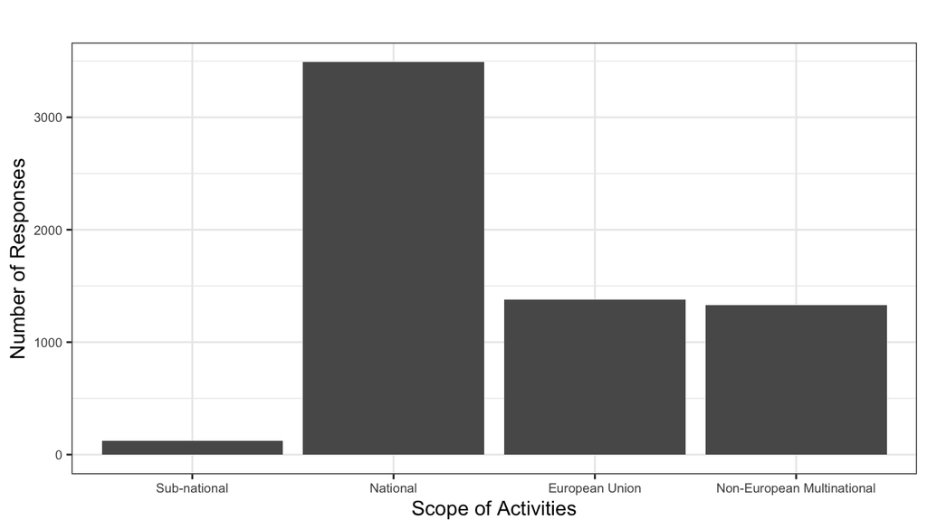

Figure 8.4: Responses to Consultation by Level of Activities

## 8.3 Example of Text Reuse

Table 8.2: Examples of text reuse associated with different Smith-Watermann algorithm scores

| Match Detected in Text 1 | Match Detected in Text2 | Smith Waterman Score |
| --- | --- | --- |
| are you satisfied with the appointment procedures for the stakeholder groups ##### | are you satisfied with the appointment procedures for the stakeholder ###### group | 28 |
| in general volkswagen ## agrees ##### with the exemptions as proposed ########## and the requirements cesr outlined in its technical report | in general ########## we ###### agree with the ########## ## proposed exemptions and the requirements cesr outlined in its technical report | 29 |
| the endorsement process for international financial reporting standards in europe | the endorsement process for international financial reporting standards in europe | 30 |
| in the current proposal this is ###### to be found in the following sub sections | in the current proposal this ## should ## be found in the following sub sections | 31 |
| mmfs are important providers of short term funding to financial institutions businesses ########### and governments ######### | mmfs are important providers of short term funding to financial institutions ########## governments and ########### companies | 32 |
| they should not give preference to which frameworks companies can use | they should not give preference to which frameworks companies can use | 33 |
| computer software can be recorded as an other asset ###### subject to regular risk rating and | computer software can be recorded as ## other ##### assets subject to regular risk rating and | 34 |
| crd iv pc and supports the efforts that ## would ### lead ########## ## #### to a global level playing field in a strengthened financial system | ### iv ## and supports the efforts #### of ##### the #### commission to lead to a global ##### playing field in a strengthened financial system | 35 |
| the study s analysis of the regulatory framework applicable to ######### ## the uk ###### is not exhaustive | the study s analysis of the regulatory framework applicable to insurance in the uk market is not exhaustive | 36 |
| instances in which esma further stretches ######### the boundaries of its mandate under article 16 | instances in which esma further ######### stretched the boundaries of its mandate under article 16 | 37 |
| between the various european markets are #### related ###### to operations market practices non harmonised settlement cycles and operating hours of settlement | between the various european markets ### with ####### regard to operations market practices ### ########## settlement cycles and operating hours of settlement | 38 |
| short description of the general activity of your organisation company open reply optional | short description of the general activity of your organisation company open reply optional | 39 |
| regulation and supervision must be activity based to ensure that consumers are ### effectively ## ######### #### #### ####### #### ### #### ###### and equally ######### protected ########## both when … | regulation and supervision must be activity based to ensure that consumers ### can ########### be confident that they benefit from the same rights and ####### effective ######### protection both when … | 40 |
| a distributor has to offer a ###### dvice on request or on own initiative when the circumstances ###### ####### indicate there is a | a distributor has to offer # advice ##### on request or on own initiative when the ############# circum stances indicate there is a | 41 |
| seventh we have a comment on the integrity of the issuance of the securities | seventh we have a comment on the integrity of the issuance of the securities | 42 |
| more generally non financial companies need hedging instruments which are ########## tailored to fit the complex and specific nature of each ######## ## ###### large commercial contract | more generally non financial companies need hedging instruments which ### completely ######## ## fit the complex and specific nature of each forecast or actual large commercial contract | 43 |
| relevance to the company s main risks details ### on ####### # how ##### policies are integrated and complied with ### ######### throughout the organization and by key business relationships | relevance to the company s main risks ####### and ## impacts 3 how these policies are integrated ### complied with and evaluated throughout the organization and by key business relationships | 44 |
| requiring transnational corporations tcs to disclose their tax planning strategies can be useful additional information | requiring transnational corporations tcs to disclose their tax planning strategies can be useful additional information | 45 |
| should focus ## on clarifying the basis on which access to the european market is to be provided | should ##### be on clarifying the basis on which access to the european market is to be provided | 46 |
| to make high quality securitisations attractive to the market the costs for implementing and enforcing criteria | to make high quality securitisations attractive to the market the costs for implementing and enforcing criteria | 48 |
| even the markets in financial instruments directive relies #### on the principle that investors have ownership rights in securities | even the markets in financial instruments directive ###### rely on the principle that investors have ownership rights in securities | 49 |
| should be a comprehensive 15 single point of information bundled at one european authority and not piecework ##### #### of different assessments by different # ######## competent authorities | should be a comprehensive ## single point of information bundled at one european authority and not ######### piece meal of different assessments by ######### d ifferent competent authorities | 50 |
| that asset is a bundle of rights mainly claims of the account holder client on the intermediary | that asset is a bundle of rights mainly claims of the account holder client on the intermediary | 51 |
| laws should be finalized well before their appli ########### cation and stakeholders should have the time to prepare for the new rules | laws should be finalized well before their ##### application ###### and stakeholders should have the time to prepare for the new rules | 52 |
| to improve transparency ##### ####### and market oversight in otc derivatives through emir and also physically trade ###### d power and gas products through remit and ## also #### ## on fundamental da… | to improve ############ trans parency and market oversight in otc derivatives through emir and also physically ##### traded # power and gas products through remit ### as #### well as on fundamental da… | 53 |
| citizens and customers can in case of unethical behaviour stage public campaigns which will lead to reputational damage | citizens and customers can in case of unethical behaviour stage public campaigns which will lead to reputational damage | 54 |
| the three largest french providers are present in over twenty member states making securities intermediation a leading european industry 2 # | the three largest french providers are present in over twenty member states making securities intermediation a leading european industry # 1 | 55 |
| for eltifs not open to retail investors but only to professional ######### and semi ##### professional #### ones ### ####### ## #### #### ####### additional flexibility regarding ### # ### ### portfol… | for eltifs not open to retail investors but only to professional investors and #### those ############ that #### are treated as such upon request additional flexibility ######### vis a vis the portfol… | 56 |
| the host insurer then sends the claim back to the home insurer for reimbursement as per their partnership agreement | the host insurer then sends the claim back to the home insurer for reimbursement as per their partnership agreement | 57 |
| it is to be expected that in future #### ##### there will be no alternative to bilateral trade in many cases e g unsuitable derivatives or trading with non banks | it is to be expected that in ###### many cases there will be no alternative to bilateral trade ## #### ##### e g unsuitable derivatives or trading with non banks | 58 |
| this point ######## is not only relevant for retail investors like mentioned in the consultation document but also for ######### ##### ### ######## qualified investors ## ### ######## e g wealth manag… | this ##### argument is not only relevant for retail investors like mentioned in the consultation document but also for investors which are declared qualified investors in the document e g wealth #####… | 59 |
| this should include the definition of the law that governs the enforcement of the collateral and the rights flowing therefrom | this should include the definition of the law that governs the enforcement of the collateral and the rights flowing therefrom | 60 |
| it s likely to increase taxes paid both within and without ####### europe as more profits would be relocated out of tax havens | it s likely to increase taxes paid both within and ####### outside europe as more profits would be relocated out of tax havens | 61 |
| we believe ######## that automated advice will not entirely substitute human interaction as an advisor may #### ## respond directly to specific questions and provide information the consumer requires … | we ####### conclude that automated advice will not ######## substitute human interaction as an advisor may need to respond directly to specific questions and provide information the consumer requires … | 62 |
| in other words how to isolate the various reasons for which account providers would apply different prices to their account holders | in other words how to isolate the various reasons for which account providers would apply different prices to their account holders | 63 |
| that recovery plans should be required at entity level but consider ####### that it may well be dependent on how the group is managed | that recovery plans should be required at entity level but ######## concede that it may well be dependent on how the group is managed | 64 |
| where a ### eu account holder credits securities to a securities ac ####### count by a ## non eu account holder the services are subject to the non eu law of the ## ###### state where the account pro… | where a non eu account holder credits securities to a securities ### account ##### by # an ### eu account holder the services are subject to the ### ## law of the eu member state where the account pro… | 65 |
| worth stressing is the fact that a similar distinction is already made by the geneva securities convention and the financial collateral directive | worth stressing is the fact that a similar distinction is already made by the geneva securities convention and the financial collateral directive | 66 |
| attempting to identify in advance products that warrant differentiated regulatory treatment could lead ###### ####### to insufficient regulatory attention being devoted to other supposedly less risky … | attempting to identify in advance products that warrant differentiated regulatory treatment could #### likely leading to insufficient regulatory attention being devoted to other supposedly less risky … | 67 |
| article 122a in conjunction with recital 25 of directive ### 2009 ## 111 ec had already resolved this problem by stipulating that the retention requirement was not to apply to purchased receivables | article 122a in conjunction with recital 25 of ######### crd #### ii ### ## had already resolved this problem by stipulating that the retention requirement was not to apply to purchased receivables | 68 |
| concerning netting sets it remains unclear to what extent these proposals affect banks that have no internal model for the assessment of ccr | concerning netting sets it remains unclear to what extent these proposals affect banks that have no internal model for the assessment of ccr | 69 |
| a recent imf report estimates the impact of tcs profit shifting ############ on ## developing countries at over 200bn ### ## a year three times as high as on ## oecd countries in terms of gdp | a recent imf report estimates the impact of tcs profit ######## reallocation ## in developing countries at over ##### 200 bn a year three times as high as ## in oecd countries in terms of gdp | 70 |
| we encourage the european commission to take ###### the same approach as the one adapted ####### for the shareholders rights directive the financial collateral directive and the finality directive | we encourage the european commission to #### follow the same approach as the one ####### adopted for the shareholders rights directive the financial collateral directive and the finality directive | 71 |
| liability of each actor involved in the given service e g cognitive engine provider system integrator that trained the machine company offering the service | liability of each actor involved in the given service e g cognitive engine provider system integrator that trained the machine company offering the service | 72 |
| horizontal legislation it should moreover aim to complement the different pieces of sectorial legislation already adopt ####### ed mifid emir csdr etc in order to avoid overlaps and inconsistencies | horizontal legislation it should moreover aim to complement the different pieces of sectorial legislation already ##### adopted ## mifid emir csdr etc in order to avoid overlaps and inconsistencies | 73 |
| this suggests that the potential benefits linked to the achiev ########### ement of a single pensions market would be rather limited given ##### 3rd pillar pensions are far less common than 2nd pillar… | this suggests that the potential benefits linked to the ###### achievement ##### of a single pensions market would be rather limited ##### being 3rd pillar pensions ### far less common than 2nd pillar… | 74 |
| currently without leaks and whistleblowers even governments only see a small window into the inner workings of companies which makes proving tax abuse nearly impossible | currently without leaks and whistleblowers even governments only see a small window into the inner workings of companies which makes proving tax abuse nearly impossible | 75 |
| for m payments a ### potential weak point is the mobile phone or its operating system which is not specifically designed for the purpose of providing a trustworthy user interface | for m payments # the ######### weak point is the mobile phone or its operating system which is not specifically designed for the purpose of providing a trustworthy user interface | 76 |
| for the benefit of ensuring effective investor protection we should rather create an environment providing for widespread financial and economic lite ######## racy than pursuing an ecosystem ###### ##… | for the benefit of ensuring effective investor protection we should rather create an environment providing for widespread financial and economic #### literacy #### than pursuing an ######### ecosys te… | 77 |
| the commission s proposal goes beyond cesr s advice in that it would remove the option for the ####### ### transmitting firm to report the client id directly to the | the commission s proposal goes beyond cesr s advice in that it would remove the option for the receive and transmitting firm to report the client id directly to the | 78 |
| this government backed scheme has proven its ef ############# fectiveness in channelling cheap funds to smes during the current economic downturn and represents a model that could be adopted successfu… | this government backed scheme has proven its ## effectiveness ########### in channelling cheap funds to smes during the current economic downturn and represents a model that could be adopted successfu… | 79 |
| review of the interaction of recent regulatory measures affecting collateral flow measures in particular mifid emir sft have been very helpful but should be reviewed regarding potential ### unintended… | review of the interaction of recent regulatory measures affecting collateral flow ######## in particular mifid emir sft #### #### #### ####### ### ###### ## ######## regarding ######### any unintended… | 80 |

Note:  
In our paper we have set the following parameters: “match” score 3 for exactly matching consecutive words, mismatch score of -2 when the sequences of text include words that do not match, and gap score of -3 when the sequences of text include placeholder words in matching a shorter sequence to a longer sequence. Sign # indicates words that do not match

## 8.4 Descriptive statistics of financial networks

Table 8.3: Descriptive Statistics

| Headquarters | Financial Actors Nº Financial Actors | Financial Actors Nº Financial Responses | Financial Actors % Financial Responses with ties to other financial actors | Financial Actors Average Nº of Fin. Counterpart | Financial Actors Aggregate Density of Financial Network | Non-Financial Actors Nº Non-Financial Actors | Non-Financial Actors Nº Non-Financial Responses | Non-Financial Actors % Non-Financial Responses with Ties to Financial Actors | Non-Financial Actors Average Nº of Fin. Counterparts for NFC | Non-Financial Actors Aggregate Density of NFC-Financial Network | International Nº Financial Actors tied to Foreign Finance | International % Financial Actors tied to Foreign Finance | International % Financial Responses tied to Foreign Finance | International Average Nº of Foreign Financial Counterparts for Finance |
| --- | --- | --- | --- | --- | --- | --- | --- | --- | --- | --- | --- | --- | --- | --- |
| AUT | 7 | 16 | 0% | 0.00 | 0.00 | 4 | 59 | 8.47% | 0.50 | 0.38 | 4 | 57.14% | 37.5% | 2.43 |
| BEL | 12 | 41 | 9.76% | 0.33 | 0.10 | 11 | 21 | 0% | 0.00 | 0.00 | 4 | 33.33% | 9.76% | 1.08 |
| CYP | 2 | 2 | 0% | 0.00 | 0.00 | 1 | 2 | 0% | 0.00 | 0.00 | 0 | 0% | 0% | 0.00 |
| CZE | 5 | 15 | 0% | 0.00 | 0.00 | 3 | 14 | 0% | 0.00 | 0.00 | 2 | 40% | 13.33% | 1.20 |
| DEU | 59 | 320 | 19.69% | 1.90 | 0.08 | 59 | 171 | 18.13% | 0.98 | 0.06 | 26 | 44.07% | 24.06% | 2.25 |
| DNK | 12 | 74 | 29.73% | 1.50 | 0.27 | 4 | 7 | 0% | 0.00 | 0.00 | 8 | 66.67% | 21.62% | 2.75 |
| ESP | 14 | 65 | 9.23% | 0.29 | 0.06 | 7 | 12 | 0% | 0.00 | 0.00 | 7 | 50% | 32.31% | 2.64 |
| EST | 2 | 3 | 0% | 0.00 | 0.00 | 1 | 1 | 0% | 0.00 | 0.00 | 2 | 100% | 100% | 5.00 |
| FIN | 3 | 29 | 0% | 0.00 | 0.00 | 7 | 27 | 3.7% | 0.14 | 0.10 | 2 | 66.67% | 27.59% | 5.00 |
| FRA | 49 | 304 | 30.92% | 2.33 | 0.10 | 26 | 84 | 5.95% | 0.35 | 0.02 | 24 | 48.98% | 28.62% | 3.67 |
| GBR | 89 | 464 | 7.76% | 0.54 | 0.01 | 18 | 66 | 3.03% | 0.11 | 0.00 | 32 | 35.96% | 12.93% | 1.44 |
| GRC | 2 | 7 | 0% | 0.00 | 0.00 | 2 | 2 | 0% | 0.00 | 0.00 | 1 | 50% | 57.14% | 3.50 |
| HUN | 1 | 1 | 0% | 0.00 | 0.00 | 0 | 0 | 0% | 0.00 | 0.00 | 1 | 100% | 100% | 5.00 |
| IRL | 9 | 41 | 7.32% | 0.67 | 0.12 | 4 | 6 | 0% | 0.00 | 0.00 | 3 | 33.33% | 24.39% | 1.78 |
| ITA | 29 | 163 | 26.38% | 5.52 | 0.33 | 8 | 22 | 0% | 0.00 | 0.00 | 18 | 62.07% | 24.54% | 2.76 |
| LIT | 0 | 0 | 0% | 0.00 | 0.00 | 0 | 0 | 0% | 0.00 | 0.00 | 0 | 0% | 0% | 0.00 |
| LTU | 2 | 3 | 0% | 0.00 | 0.00 | 0 | 0 | 0% | 0.00 | 0.00 | 2 | 100% | 100% | 4.50 |
| LUX | 11 | 68 | 8.82% | 0.36 | 0.07 | 1 | 1 | 0% | 0.00 | 0.00 | 6 | 54.55% | 26.47% | 2.18 |
| LVA | 1 | 4 | 0% | 0.00 | 0.00 | 1 | 1 | 0% | 0.00 | 0.00 | 1 | 100% | 75% | 9.00 |
| NLD | 26 | 97 | 13.4% | 0.54 | 0.07 | 8 | 19 | 10.53% | 0.25 | 0.04 | 10 | 38.46% | 24.74% | 1.50 |
| NOR | 4 | 18 | 11.11% | 0.50 | 0.50 | 3 | 3 | 0% | 0.00 | 0.00 | 1 | 25% | 22.22% | 2.50 |
| POL | 3 | 6 | 0% | 0.00 | 0.00 | 1 | 1 | 0% | 0.00 | 0.00 | 0 | 0% | 0% | 0.00 |
| PRT | 5 | 10 | 0% | 0.00 | 0.00 | 2 | 4 | 0% | 0.00 | 0.00 | 3 | 60% | 50% | 0.80 |
| ROM | 0 | 0 | 0% | 0.00 | 0.00 | 0 | 0 | 0% | 0.00 | 0.00 | 0 | 0% | 0% | 0.00 |
| SVK | 2 | 5 | 0% | 0.00 | 0.00 | 0 | 0 | 0% | 0.00 | 0.00 | 1 | 50% | 20% | 2.50 |
| SVN | 1 | 1 | 0% | 0.00 | 0.00 | 0 | 0 | 0% | 0.00 | 0.00 | 1 | 100% | 100% | 5.00 |
| SWE | 8 | 58 | 3.45% | 0.25 | 0.03 | 10 | 16 | 6.25% | 0.10 | 0.04 | 4 | 50% | 24.14% | 3.00 |

Table 8.4: Financial Actors

| Headquarters | Most Frequent Respondents | Most Connected to Other Domestic Finance | Most Frequent Ties between Domestic Finance |
| --- | --- | --- | --- |
| AUT | Raiffeisen Capital Management (5) Austrian Raiffeisen Banking Group (4) Versicherungsverband Österreich (4) Austrian Equity Issuers Association (1) CONDA Crowdinvesting (1) |  |  |
| BEL | Euroclear (14) Febelfin (8) Beroep van zelfstandige bank en verzekeringsbemiddelaars (4) Assuralia, beroepsvereniging van verzekeringsondernemingen (3) Belgische Vereniging van Asset Managers (3) | Dexia (1) Euroclear (1) Febelfin (1) KBC Group NV (1) | Dexia ~ Euroclear (1) Febelfin ~ KBC Group NV (1) |
| CYP | Cyprus Stock Exchange (CSE) (1) Σύνδεσμος Τραπεζών Κύπρου (1) |  |  |
| CZE | České bankovní asociace (9) Česká asociace pojišťoven (3) Česká bankovní asociace (2) Czech Capital Market Association (AKAT) (1) |  |  |
| DEU | Volksbanken Raiffeisenbanken (42) Gesamtverband der Deutschen Versicherungswirtschaft (40) Deutsche Kreditwirtschaft (32) Deutsche Bank (31) Bundesverband Investment und Asset Management e.V. (30) | Deutsches Aktieninstitut e.V. (10) Deutsche Kreditwirtschaft (9) Bundesverband deutscher Banken (8) Bundesverband der Deutschen Volksbanken und Raiffeisenbanken (7) Deutscher Sparkassen- und Giroverba… | Verband deutscher Pfandbriefbanken ~ Deutsche Kreditwirtschaft (4) Deutsche Kreditwirtschaft ~ Deutscher Sparkassen- und Giroverband (4) Verband deutscher Pfandbriefbanken ~ Bundesverband der Deutsche… |
| DNK | Dansk Aktionærforening (16) Finansraadet (13) Forsikring & Pension (11) Realkreditforeningen (11) Finance Denmark (10) | Finance Denmark (4) Finansraadet (4) Børsmæglerforening Danmark (2) Danske bank (2) Forsikring & Pension (2) Nordea (2) | Finansraadet ~ Børsmæglerforening Danmark (4) Realkreditforeningen ~ Finance Denmark (2) Børsmæglerforening Danmark ~ Finance Denmark (2) Finansraadet ~ Danske bank (1) Finansraadet ~ Finance Denmark … |
| ESP | Banco Bilbao Vizcaya Argentaria (13) Asociación Española de Banca (11) Banco Santander (9) Asociacion de Instituciones de Inversion Colectiva y Fondos de Pensiones (8) BME Bolsas y Mercados Españoles … | Banco Bilbao Vizcaya Argentaria (2) Asociación Española de Banca (1) Banco Santander (1) | Asociación Española de Banca ~ Banco Bilbao Vizcaya Argentaria (2) Banco Bilbao Vizcaya Argentaria ~ Banco Santander (1) |
| EST | Eesti Pangalit (2) Eesti Kindlustusseltside Liit (1) |  |  |
| FIN | Finanssialan Keskusliitto (FKL) (28) Finanssiala ry (3) Finnish Pension Alliance (3) |  |  |
| FRA | Fédération Bancaire Française (47) Association française de la gestion finançiere (32) BNP Paribas Group (27) Le Groupe Credit Agricole (26) Amundi (23) | Association française de la gestion finançiere (13) BNP Paribas Group (10) Fédération Bancaire Française (10) Association française des marches financiers (9) Association Française des Professionnels … | Association Française des Professionnels des Titres ~ Fédération Bancaire Française (9) BNP Paribas Group ~ Fédération Bancaire Française (9) Association française des marches financiers ~ Fédération … |
| GBR | British Bankers’ Association (34) Association of British Insurers (31) London Stock Exchange (27) Investment Management Association (25) Barclays (23) | Investment Management Association (7) Association of British Insurers (5) AVIVA (4) British Bankers’ Association (4) M&G Investments (3) | Crowdcube Ltd ~ UK Crowdfunding Association (2) Investment Management Association ~ M&G Investments (2) Association of British Insurers ~ AVIVA (1) Association of British Insurers ~ British Bankers’ A… |
| GRC | Athens Stock Exchange (6) ICAP Group (1) |  |  |
| HUN | Magyar Biztosítók Szövetsége (2) |  |  |
| IRL | Banking and Payments Federation Ireland (12) Irish Stock Exchange (9) Irish Funds Industry Association CLG (8) MetLife (7) Financial Services Ireland (2) | Banking and Payments Federation Ireland (2) Irish Debt Securities Association (2) Irish Securitisation Industry Working Group (2) | Banking and Payments Federation Ireland ~ Irish Debt Securities Association (1) Banking and Payments Federation Ireland ~ Irish Securitisation Industry Working Group (1) Irish Debt Securities Associat… |
| ITA | Associazione Bancaria Italiana (37) Unicredit group (23) Associazione del risparmio gestito (19) Intesa Sanpaolo Group (19) Associazione Italiana degli Intermediari Mobiliari (16) | Assoprevidenza (14) Associazione Bancaria Italiana (13) Associazione Italiana degli Intermediari Mobiliari (13) Association Italiana del Private Equity, Venture Capital e Private Debt (12) Associazion… | Associazione Bancaria Italiana ~ Unicredit group (4) Associazione Bancaria Italiana ~ Associazione Italiana degli Intermediari Mobiliari (3) Associazione Bancaria Italiana ~ Intesa Sanpaolo Group (3) … |
| LIT |  |  |  |
| LTU | Lietuvos Banku Asociacija (2) Association of Lithuanian Banks (1) |  |  |
| LUX | Association Luxembourgeoise des Fonds d’Investissement (26) Association des Banques et Banquiers, Luxembourg (20) AXA Investment Managers (10) Clearstream (3) Association des Compagnies d’ Assurances … | Association Luxembourgeoise des Fonds d’Investissement (2) Association des Banques et Banquiers, Luxembourg (1) Luxembourg Private Equity and Venture Capital Association (1) | Association Luxembourgeoise des Fonds d’Investissement ~ Luxembourg Private Equity and Venture Capital Association (2) Association des Banques et Banquiers, Luxembourg ~ Association Luxembourgeoise de… |
| LVA | Latvijas Komercbanku Asociacija (4) |  |  |
| NLD | ING Groep (18) Nederlandse Vereniging van Banken (14) APG Asset Management NV (8) Vereniging VEB NCVB (8) Dutch Advisory Committee Securities Industry (7) | Mn Services N.V. (2) Nederlandse Vereniging van Banken (2) Stichting voor Ondernemingspensioenfondsen (OPF) (2) Unie van Beroepspensioenfondsen (UvB) (2) Vereniging van Bedrijfstakpensioenfondsen (2) | Mn Services N.V. ~ Pensioenfonds Metaal en Techniek (2) APG Asset Management NV ~ Mn Services N.V. (1) Dutch Advisory Committee Securities Industry ~ Nederlandse Vereniging van Banken (1) Nederlandse … |
| NOR | Finans Norge (16) Bits AS (1) Sparebankforeningen (1) Visa Norway Bank Group (1) | Finans Norge (1) Sparebankforeningen (1) | Finans Norge ~ Sparebankforeningen (1) |
| POL | KDPW CCP S.A. (4) Konferencja Przedsiębiorstw Finansowych w Polsce (1) Krajowy Związek Banków Spółdzielczych (1) |  |  |
| PRT | Associação Portuguesa de Bancos (6) Associação Portuguesa de Fundos de Investimento, Pensões e Patrimónios (3) Banco Comercial Português (1) BiG Start Ventures (1) Interbolsa (1) |  |  |
| ROM |  |  |  |
| SVK | Slovenská asociácia poisťovní (3) Slovenska bankova asociacia (2) |  |  |
| SVN | Slovensko Zavarovalno Združenje (1) |  |  |
| SWE | Nasdaq OMX (22) Svenska Bankföreningen (17) Svenska Fondhandlareföreningen (13) Association of Swedish Covered Bond issuers (3) Fondbolagens förening (3) | Svenska Bankföreningen (1) Svenska Fondhandlareföreningen (1) | Svenska Bankföreningen ~ Svenska Fondhandlareföreningen (1) |

Table 8.5: Non-Financial Actors

| Headquarters | Most Frequent NFC Respondents | NFC Most Connected to Financial Actors | Most Frequent Ties between NFC and FIN |
| --- | --- | --- | --- |
| AUT | Wirtschaftskammer Österreich (66) Verbund AG (4) Industriellenvereinigung (3) Cablexperts (1) | Wirtschaftskammer Österreich (2) | Wirtschaftskammer Österreich ~ Raiffeisen Capital Management (3) Wirtschaftskammer Österreich ~ Austrian Raiffeisen Banking Group (2) |
| BEL | Conseil Supérieur des Indépendants et des PME (4) European Confederation of Directors’ Associations (3) FoodDrink Europe (3) Lufthansa (3) Association of European Airlines (2) |  |  |
| CYP | Cyprus Chamber of Commerce and Industry (2) |  |  |
| CZE | Hospodářská komora České republiky (6) Svaz průmyslu a dopravy České Republiky (6) CEZ Group (4) |  |  |
| DEU | Deutscher Industrie- und Handelskammertag (30) Bundesverband der Deutschen Industrie (23) Genossenschaftsverband Bayern (11) Bundesverband der Energie- und Wasserwirtschaft (7) Siemens AG (7) | Bundesverband der Deutschen Industrie (8) Deutscher Industrie- und Handelskammertag (7) Genossenschaftsverband Bayern (7) Genossenschaftsverband – Verband der Regionen e.V. (6) Bayer (5) Deutsche Post… | Bundesverband der Deutschen Industrie ~ Deutsches Aktieninstitut e.V. (4) Deutscher Industrie- und Handelskammertag ~ Deutsche Kreditwirtschaft (2) Bayer ~ Deutsches Aktieninstitut e.V. (2) Bundesverb… |
| DNK | Dansk Erhverv (4) Dansk Energi (1) Novo Nordisk AS (1) Ørsted A/S (1) |  |  |
| ESP | Repsol (4) Confederación de Empresarios de la Construcción de Aragón (3) Abertis (1) AlterCompany (1) Consejo General de la Abogacia Espanola (1) |  |  |
| EST | Eesti Energia Aktsiaselts (1) |  |  |
| FIN | Confederation of Finnish Industries (16) Keskuskauppakamari (4) ENERGIATEOLLISUUS (3) Fortum OYJ (2) Finnish Business and Society ry (1) | Confederation of Finnish Industries (1) | Confederation of Finnish Industries ~ Finanssialan Keskusliitto (FKL) (1) |
| FRA | Mouvement des entreprises de France (60) Association Nationale des Societes par Action (16) EDF Group (9) Association Française des Trésoriers d’Entreprise (8) Confédération Générale des Petites et Mo… | Mouvement des entreprises de France (9) | Mouvement des entreprises de France ~ Association française de la gestion finançiere (4) Mouvement des entreprises de France ~ BNP Paribas Group (2) Mouvement des entreprises de France ~ Fédération Ba… |
| GBR | Confederation of British Industry (20) Association of Corporate Treasurers (13) Quoted Companies Alliance (7) Rolls-Roys (7) British Property Federation (5) | British Property Federation (1) The Association of General Counsel and Company Secretaries working in FTSE 100 Companies (1) | British Property Federation ~ Investment Property Forum (1) The Association of General Counsel and Company Secretaries working in FTSE 100 Companies ~ London Stock Exchange (1) |
| GRC | Federation Of Hellenic Associations Of Young Entrepreneurs (1) Hellenic Telecommunications Organization S.A. (OTE ) (1) |  |  |
| HUN |  |  |  |
| IRL | Irish business and employers confederation (3) An Lár TV (1) Chambers Ireland (1) FEXCO Merchant Services Unlimited Company (1) |  |  |
| ITA | Associazione fra le Società Italiane per Azioni (9) Enel SpA (5) Poste Italiane (3) Confederazione Generale dell’Industria Italiana (2) Associazione Italiana per il factoring (1) |  |  |
| LIT |  |  |  |
| LTU |  |  |  |
| LUX | Association of Corporate Treasurers in Luxembourg (1) |  |  |
| LVA | Latvijas Darba devēju konfederācija (1) |  |  |
| NLD | CRO Forum (5) VNO-NCW (4) Linda van Goor Regulatory Communication (3) MKB-Nederland (3) AEGON N.V. (2) | AEGON N.V. (1) CRO Forum (1) | AEGON N.V. ~ ING Groep (1) CRO Forum ~ ING Groep (1) |
| NOR | Agder Energi (1) ECOHZ (1) Eidsiva Vannkraft AS (1) |  |  |
| POL | Towarzystwo Obrotu Energią (1) |  |  |
| PRT | Associação de Empresas Emitentes de Valores Cotados em Mercado (2) Conselho Empresarial para o Desenvolvimento Sustentavel (2) |  |  |
| ROM |  |  |  |
| SVK |  |  |  |
| SVN |  |  |  |
| SWE | Svenskt Näringsliv (6) E.On Kärnkraft AG SE (2) Göteborg Energi AB (2) Dalakraft (1) Enkla Elbolaget AB (1) | Svenske Energy (1) | Svenske Energy ~ Nasdaq OMX (1) |

Table 8.6: Financial Ties with Foreign Financial Groups

| Headquarters | Most Frequent Country Ties | Financial Firm with Most Foreign Ties | Most Frequent Ties between domestic and foreign finance |
| --- | --- | --- | --- |
| AUT | AUT ~ BEL (6) AUT ~ FRA (3) AUT ~ GBR (2) AUT ~ CHE (1) AUT ~ CZE (1) | CONDA Crowdinvesting (10) Versicherungsverband Österreich (5) Austrian Raiffeisen Banking Group (1) Raiffeisen Capital Management (1) | Austrian Raiffeisen Banking Group ~ European Association of Cooperative Banks (2) Raiffeisen Capital Management ~ European Association of Cooperative Banks (2) CONDA Crowdinvesting ~ Afrikwity (1) CON… |
| BEL | BEL ~ FRA (4) BEL ~ DEU (2) BEL ~ GBR (2) BEL ~ (1) BEL ~ AUT (1) | My Micro Invest (9) Belgian Association of Financial Analysts (2) Euroclear (1) Fortis (1) | Belgian Association of Financial Analysts ~ CFA Institute (1) Belgian Association of Financial Analysts ~ European Federation of Financial Analysts Societies (1) Euroclear ~ Nasdaq OMX (1) Fortis ~ BN… |
| CYP |  |  |  |
| CZE | CZE ~ AUT (1) CZE ~ BEL (1) CZE ~ HUN (1) CZE ~ LUX (1) CZE ~ SVK (1) | Česká asociace pojišťoven (6) | Česká asociace pojišťoven ~ Association des Compagnies d’ Assurances du Grand-Duché de Luxembourg (1) Česká asociace pojišťoven ~ European insurance and reinsurance federation (1) Česká asociace poji… |
| DEU | DEU ~ BEL (91) DEU ~ FRA (44) DEU ~ GBR (16) DEU ~ ITA (7) DEU ~ USA (6) | Munich RE (17) Deutsche Kreditwirtschaft (11) Allianz (10) Bergfurst (10) ERGO Lebensversicherungen (8) | Bundesverband Investment und Asset Management e.V. ~ European Fund and Asset Management Association (12) Deutsche Kreditwirtschaft ~ European Association of Public Banks and Funding Agencies (8) Deuts… |
| DNK | DNK ~ BEL (17) DNK ~ FIN (5) DNK ~ SWE (5) DNK ~ EST (4) DNK ~ LVA (4) | Finance Denmark (11) Finansraadet (7) Forsakrings Forbundet (3) Forsikring & Pension (3) Nordea (3) | Finance Denmark ~ European Covered Bond Council (ECBC) (3) Finance Denmark ~ European Mortgage Federation (3) Finance Denmark ~ Svenska Bankföreningen (3) Finance Denmark ~ Eesti Pangalit (2) Finance … |
| ESP | ESP ~ BEL (34) ESP ~ FRA (6) ESP ~ GBR (4) ESP ~ NLD (2) ESP ~ DEU (1) | Asociación Española de Banca (13) Banco Bilbao Vizcaya Argentaria (6) Banco Santander (6) Asociacion Empresarial del Seguro (4) Asociacion Hipotecaria Española (3) | Banco Bilbao Vizcaya Argentaria ~ European Banking Federation (6) Asociacion Empresarial del Seguro ~ European insurance and reinsurance federation (3) Asociación Española de Banca ~ European Banking … |
| EST | EST ~ DNK (4) EST ~ FIN (3) EST ~ NOR (3) EST ~ LTU (2) EST ~ LVA (2) | Eesti Pangalit (6) Eesti Kindlustusseltside Liit (4) | Eesti Pangalit ~ Finance Denmark (2) Eesti Pangalit ~ Finans Norge (2) Eesti Pangalit ~ Finanssialan Keskusliitto (FKL) (2) Eesti Pangalit ~ Latvijas Komercbanku Asociacija (2) Eesti Pangalit ~ Lietuv… |
| FIN | FIN ~ BEL (5) FIN ~ DNK (5) FIN ~ EST (3) FIN ~ NOR (3) FIN ~ SWE (3) | Finanssialan Keskusliitto (FKL) (12) Finanssiala ry (3) | Finanssialan Keskusliitto (FKL) ~ European Banking Federation (3) Finanssialan Keskusliitto (FKL) ~ Finans Norge (3) Finanssialan Keskusliitto (FKL) ~ Eesti Pangalit (2) Finanssialan Keskusliitto (FKL… |
| FRA | FRA ~ BEL (88) FRA ~ GBR (49) FRA ~ DEU (44) FRA ~ USA (18) FRA ~ ITA (10) | Fédération Bancaire Française (23) Association française de la gestion finançiere (18) BNP Paribas Group (16) Association Française des Professionnels des Titres (15) Société Générale (14) | Fédération Bancaire Française ~ European Banking Federation (12) Association française de la gestion finançiere ~ European Fund and Asset Management Association (6) Fédération Bancaire Française ~ Ass… |
| GBR | GBR ~ BEL (53) GBR ~ FRA (26) GBR ~ USA (23) GBR ~ CHE (11) GBR ~ DEU (9) | British Bankers’ Association (23) AVIVA (13) Capital Cell (9) Crowd Invest (9) RSA Group (9) | British Bankers’ Association ~ European Banking Federation (6) British Bankers’ Association ~ International Swaps and Derivatives Association (5) Investment Management Association ~ European Fund and … |
| GRC | GRC ~ BEL (5) GRC ~ DEU (1) GRC ~ GBR (1) GRC ~ IRL (1) GRC ~ USA (1) | Athens Stock Exchange (7) | Athens Stock Exchange ~ European Central Securities Depositories Association (2) Athens Stock Exchange ~ Federation of European Securities Exchanges (2) Athens Stock Exchange ~ European Association of… |
| HUN | HUN ~ AUT (1) HUN ~ CZE (1) HUN ~ LUX (1) HUN ~ SVK (1) HUN ~ SVN (1) | Magyar Biztosítók Szövetsége (5) | Magyar Biztosítók Szövetsége ~ Association des Compagnies d’ Assurances du Grand-Duché de Luxembourg (1) Magyar Biztosítók Szövetsége ~ Česká asociace pojišťoven (1) Magyar Biztosítók Szövetsége ~ Sl… |
| IRL | IRL ~ BEL (8) IRL ~ USA (7) IRL ~ GBR (3) IRL ~ FRA (2) IRL ~ GRC (1) | Irish Funds Industry Association CLG (10) Banking and Payments Federation Ireland (3) Irish Stock Exchange (3) | Irish Stock Exchange ~ Federation of European Securities Exchanges (3) Banking and Payments Federation Ireland ~ European Banking Federation (2) Irish Funds Industry Association CLG ~ Institutional Mo… |
| ITA | ITA ~ BEL (43) ITA ~ GBR (27) ITA ~ FRA (10) ITA ~ DEU (7) ITA ~ CHE (4) | Associazione Italiana degli Intermediari Mobiliari (12) Associazione Bancaria Italiana (11) Crowd Fund Me (10) Generali (10) Unicredit group (7) | Associazione Bancaria Italiana ~ European Banking Federation (8) Associazione Italiana degli Intermediari Mobiliari ~ Association for Financial Markets in Europe (4) Associazione Bancaria Italiana ~ A… |
| LIT |  |  |  |
| LTU | LTU ~ DNK (3) LTU ~ LVA (3) LTU ~ SWE (3) LTU ~ EST (2) LTU ~ FIN (2) | Lietuvos Banku Asociacija (6) Association of Lithuanian Banks (3) | Lietuvos Banku Asociacija ~ Eesti Pangalit (2) Lietuvos Banku Asociacija ~ Finance Denmark (2) Lietuvos Banku Asociacija ~ Finans Norge (2) Lietuvos Banku Asociacija ~ Finanssialan Keskusliitto (FKL) … |
| LUX | LUX ~ BEL (18) LUX ~ DEU (4) LUX ~ FRA (3) LUX ~ USA (2) LUX ~ AUT (1) | Association des Banques et Banquiers, Luxembourg (8) Association Luxembourgeoise des Fonds d’Investissement (6) Association des Compagnies d’ Assurances du Grand-Duché de Luxembourg (5) AXA Investmen… | Association des Banques et Banquiers, Luxembourg ~ European Banking Federation (5) Association Luxembourgeoise des Fonds d’Investissement ~ European Fund and Asset Management Association (3) Associati… |
| LVA | LVA ~ DNK (4) LVA ~ LTU (3) LVA ~ EST (2) LVA ~ FIN (2) LVA ~ NOR (2) | Latvijas Komercbanku Asociacija (9) | Latvijas Komercbanku Asociacija ~ Eesti Pangalit (2) Latvijas Komercbanku Asociacija ~ Finance Denmark (2) Latvijas Komercbanku Asociacija ~ Finans Norge (2) Latvijas Komercbanku Asociacija ~ Finanssi… |
| NLD | NLD ~ BEL (28) NLD ~ GBR (6) NLD ~ DEU (4) NLD ~ FRA (4) NLD ~ USA (3) | ING Groep (13) Betaalvereniging Nederland (8) Nederlandse Vereniging van Banken (7) Rabobank (4) Vereniging VEB NCVB (2) | Nederlandse Vereniging van Banken ~ European Banking Federation (6) Vereniging VEB NCVB ~ European Investors’ Association (5) Betaalvereniging Nederland ~ European Banking Federation (2) Euro CCP Ltd … |
| NOR | NOR ~ DNK (4) NOR ~ EST (3) NOR ~ FIN (3) NOR ~ LTU (2) NOR ~ LVA (2) | Finans Norge (10) | Finans Norge ~ Finanssialan Keskusliitto (FKL) (3) Finans Norge ~ Eesti Pangalit (2) Finans Norge ~ Finance Denmark (2) Finans Norge ~ Latvijas Komercbanku Asociacija (2) Finans Norge ~ Lietuvos Banku… |
| POL |  |  |  |
| PRT | PRT ~ BEL (5) PRT ~ USA (1) | Interbolsa (2) Associação Portuguesa de Bancos (1) Associação Portuguesa de Fundos de Investimento, Pensões e Patrimónios (1) | Associação Portuguesa de Bancos ~ European Banking Federation (3) Associação Portuguesa de Fundos de Investimento, Pensões e Patrimónios ~ European Fund and Asset Management Association (1) Interbolsa… |
| ROM |  |  |  |
| SVK | SVK ~ AUT (1) SVK ~ CZE (1) SVK ~ HUN (1) SVK ~ LUX (1) SVK ~ SVN (1) | Slovenská asociácia poisťovní (5) | Slovenská asociácia poisťovní ~ Association des Compagnies d’ Assurances du Grand-Duché de Luxembourg (1) Slovenská asociácia poisťovní ~ Česká asociace pojišťoven (1) Slovenská asociácia poisťovní ~… |
| SVN | SVN ~ AUT (1) SVN ~ CZE (1) SVN ~ HUN (1) SVN ~ LUX (1) SVN ~ SVK (1) | Slovensko Zavarovalno Združenje (5) | Slovensko Zavarovalno Združenje ~ Association des Compagnies d’ Assurances du Grand-Duché de Luxembourg (1) Slovensko Zavarovalno Združenje ~ Česká asociace pojišťoven (1) Slovensko Zavarovalno Zdr… |
| SWE | SWE ~ BEL (14) SWE ~ DNK (6) SWE ~ FIN (3) SWE ~ LTU (3) SWE ~ DEU (2) | Svenska Bankföreningen (12) Association of Swedish Covered Bond issuers (6) Nasdaq OMX (4) Svenska Fondhandlareföreningen (2) | Nasdaq OMX ~ Federation of European Securities Exchanges (4) Svenska Bankföreningen ~ Finance Denmark (3) Svenska Bankföreningen ~ Eesti Pangalit (2) Svenska Bankföreningen ~ European Banking Federati… |

## 8.5 Statistical Analysis

Table 8.7: Summary Statistics for the Variables in the Analysis

| Variable | Observations | Mean | Standard Deviation | Min | Max | Source |
| --- | --- | --- | --- | --- | --- | --- |
| Number of Finance Partners Coordinated With | 1140 | 3.1657890 | 10.2670900 | 0.0000000 | 161.000000 | European Commission’s Website (authors’ elaboration) |
| Number of Domestic Finance Partners Coordinated With | 1140 | 1.3000000 | 5.1593910 | 0.0000000 | 57.000000 | European Commission’s Website (authors’ elaboration) |
| Number of Foreign Finance Partners Coordinated With | 1140 | 1.3745610 | 5.3055090 | 0.0000000 | 35.000000 | European Commission’s Website (authors’ elaboration) |
| International Actor | 1140 | 0.4394737 | 0.4965409 | 0.0000000 | 1.000000 | INTEREURO + additional coding by authors |
| Proportion of Bank Credit | 1096 | 0.6450735 | 0.1457857 | 0.4685104 | 1.064832 | World Bank |
| Financialization (Value-Added) | 1102 | 0.0605528 | 0.0282342 | 0.0243990 | 0.268684 | OECD Structural Analysis Database |
| Corporatism | 1110 | 0.1184144 | 1.0664490 | -1.6500000 | 2.060000 | Jahn (2016). |
| Business Association | 1140 | 0.4307018 | 0.4953918 | 0.0000000 | 1.000000 | INTEREURO + additional coding by authors |
| Firm | 1140 | 0.3236842 | 0.4680865 | 0.0000000 | 1.000000 | INTEREURO + additional coding by the authors |
| Professional Association | 1140 | 0.0552632 | 0.2285935 | 0.0000000 | 1.000000 | INTEREURO + additional coding by the authors |
| Finance | 1140 | 0.4780702 | 0.4997381 | 0.0000000 | 1.000000 | Manual coding by the authors |
| Financial Centers | 1140 | 0.3210526 | 0.4670859 | 0.0000000 | 1.000000 | Authors’ elaboration based on EU Transparency Register |
| Brussels | 1140 | 0.2008772 | 0.4008322 | 0.0000000 | 1.000000 | EU Transparency Register |
| Number of Letters | 1140 | 4.5491230 | 7.0008310 | 1.0000000 | 66.000000 | European Commission’s Website (authors’ elaboration) |
| Number of Partners Coordinate | 1140 | 1.9324560 | 6.0744430 | 0.0000000 | 44.000000 | European Commission’s Website (authors’ elaboration) |
| EU Lobbying Personnel | 726 | 3.6191460 | 5.4479280 | 0.2500000 | 86.000000 | EU Transparency Register |
| Subsidiaries Abroad | 260 | 13.3769200 | 23.0042000 | 1.0000000 | 104.000000 | Orbis Database |

Table 8.8: Logit Results

Variable

1. Total Coordination Ties
2. Domestic Coordination Ties
3. Foreign Coordination Ties

(3b)  
Foreign Coordination Ties

4. Domestic Coordination Ties
5. Foreign Coordination Ties

International Actor

-0.21  
(0.18)

-0.40*  
(0.2)

0.78**  
(0.33)

NA

NA

Bank Credit Proportion

-0.87  
(0.7)

-1.08  
(0.74)

-0.4  
(0.75)

-0.43  
(1.12)

-2.96  
(1.91)

-2.81  
(2.25)

Financialization (VA)

0.24  
(2.4)

-0.56  
(2.53)

0.51  
(2.66)

9.92**  
(4.85)

-22.72  
(14.61)

-2.19  
(5.63)

Corporatism

0.11  
(0.09)

0.04  
(0.09)

0.01  
(0.1)

-0.22  
(0.18)

0.22  
(0.28)

0.36  
(0.24)

Business Association

1.63***  
(0.43)

1.65***  
(0.51)

1.39***  
(0.5)

1.15  
(1.08)

NA

NA

Firm

1.54***  
(0.45)

1.60***  
(0.53)

0.99*  
(0.53)

0.78  
(1.03)

NA

NA

Professional Association

-0.06  
(0.75)

0.28  
(0.82)

0.03  
(0.77)

-0.86  
(2.05)

NA

NA

Financial Actor

1.57***  
(0.19)

1.44***  
(0.23)

1.86***  
(0.22)

1.87***  
(0.49)

3.39***  
(1.03)

2.42***  
(0.7)

Has office in a financial center

-0.26  
(0.19)

-0.27  
(0.21)

0.01  
(0.2)

0.14  
(0.34)

-1.16**  
(0.54)

0.12  
(0.53)

Has office in Brussels

0.70***  
(0.2)

0.21  
(0.22)

0.92***  
(0.22)

2.39***  
(0.64)

-0.7  
(0.58)

0.43  
(0.65)

Lobbying Propensity

0.20***  
(0.03)

0.15***  
(0.02)

0.16***  
(0.03)

0.23***  
(0.06)

0.23***  
(0.06)

0.27***  
(0.07)

Propensity to coordinate with non-financial actors

0.04***  
(0.01)

NA

NA

NA

NA

NA

Propensity to coordinate with domestic non-financial actors

NA

0.46***  
(0.07)

NA

NA

0.54***  
(0.18)

NA

Propensity to coordinate with foreign non-financial actors

NA

NA

0.05***

0.08**  
(0.04)

NA

1.12***  
(0.26)

Subsidiaries Abroad

NA

NA

NA

NA

0.23**  
(0.11)

0.21**  
(0.09)

EU Lobbying Personnel

NA

NA

NA

NA

0.01  
(0.15)

-0.07  
(0.1)

Constant

-3.18***  
(0.67)

-3.63***  
(0.73)

-3.95***

-5.68***  
(1.36)

-1.59  
(1.6)

-2.35  
(1.84)

Observations

1078

1078

1078

545

160

160

Pseudo R2

0.308

0.30199999999999999

0.312

0.23300000000000001

0.44600000000000001

0.46500000000000002

BIC

1054.44

884.82

967.29

432.86

158.97

172.57

Note:

Robust standard errors in parentheses, * p < 0.10, ** p < 0.05, *** p < 0.01

Table 8.9: Additional Regression Models 6-8

Variable

6. Foreign Coordination Ties
7. Foreign Coordination Ties
8. Foreign Coordination Ties

% Financial Subsidiaries

4.21**  
(1.65)`

3.17**  
(1.56)

2.56  
(1.9)

Financialization (VA)

21.61  
(20.89)

16.3  
(20.69)

13.07  
(18.55)

Subsidaries Abroad

0.24**  
(0.12)

0.26*  
(0.15)

0.2  
(0.15)

Corporatism

1.05**  
(0.46)

0.96**  
(0.47)

1.00**  
(0.44)

Has office in a financial center

-0.92  
(0.73)

-1.03  
(0.79)

-1.18  
(0.83)

Has office in Brussels

0.41  
(1.34)

0  
(1.41)

NA

Lobbying Propensity

0.35**  
(0.18)

0.39**  
(0.19)

0.41**  
(0.16)

EU Lobbying Personnel

-0.06§  
(0.09)

-0.03  
(0.08)

-0.03  
(0.08)

Propensity to coordinate foreign-ly (foreign non-financial partners))

0.46***  
(0.1)

0.49***  
(0.1)

0.49***  
(0.09)

% Individuals Tied

NA

2.72**  
(1.34)

NA

% Individuals Tied to Foreign companies

NA

NA

6.05**  
(2.63)

Constant

-5.52***  
(2.12)

-5.79***  
(1.96)

-5.37***  
(1.25)

lnalpha

-0.36  
(1.32)

-0.44  
(1.33

-0.29  
(0.92)

Observations

67

67

67

Pseudo R2

0.29099999999999998

0.31

0.314

BIC

141.35

143.04

138.21

Note:

Robust standard errors in parentheses, * p < 0.10, ** p < 0.05, *** p < 0.01

# 9 Replication Data

Replication data available on the Harvard Dataverse ([link](https://doi.org/10.7910/DVN/FBG7I4))

# 10 Endnotes

[^1]: Respondent type was coded as: 1. Business organization, 2. Organizations representing the interests of workers, 3. Non-governmental organizations, indifferent of the domain in which they are active, 4. Institutions, defined as ‘semi-public organizations, which fulfil a public role and which do not have profit as their first goal, but which do not have the legal status of an NGO’, 5. Public authorities, 6. Mixed category.
[^2]: Since this analysis is computationally demanding, we first filter those pairs of sentences in the corpus that are most likely to contain text re-use by implementing a ‘Minhashing’ technique. This involves converting text strings to shortened numeric references (known as hashes), and then filtering out those pairs of sentences below a minimum level of similarity (see Wilkerson, Smith, and Stramp 2015).
[^3]: We excluded all sentences that shared at least 10 consecutive words with the Commission text (or an equivalent score generated by the Smith-Waterman algorithm), and excluded all sentences where the overlap with the Commission text was at least a third of the sentence.
[^4]: Since the algorithm is calibrated to add three points for each additional word that two documents share in the same order, a score of 30 indicates a sentence with 10 shared words. We apply a high minimum SW score of 60, equivalent to 20 consecutive shared words per sentence. See Table 8.2 for examples.
[^5]: See https://www.longfinance.net/programmes/financial-centre-futures/global-financial-centres-index/gfci-26-explore-data/gfci-26-rank/
[^6]: Data from the World Bank website, based on data from the IMF, International Financial Statistics and data files, and World Bank and OECD GDP estimates. We took the average of both values, individually, for the 2008-2018 period.
[^7]: STAN data is based on OECD member states’ annual national accounts by activity tables, supplemented with data from other sources (e.g. national industrial surveys/censuses) to estimate missing detail. We used the ISIC Rev. 4 data to derive country-level information on value added, both measured in current prices. Data is broken down within STAN into different industry categories: we use financial and insurance activities, and divide this value by the total for all industries, to derive a country-year level observation representing the percentage contribution of the financial industry to total value-added in the economy, in a given year (see Young 2015)
[^8]: We also generated a variable that evaluates country-level financialization by production measures (rather than value-added), but these were highly correlated (Pearson correlation coefficient = 0.9429).
[^9]: Because of the possibility of measurement error, we replicated our analysis without the financialization indicator, and found the results to be substantively the same. For each of these variables, we took the average of all available years for the period of analysis, as yearly data was only available until 2017 for only a small number of countries.
[^10]: This variable captures the possibility that the greater openness of a financial system to international flows could affect the opportunities for coordination available to financial groups, independently of how internationalized its activities. The ‘Internationalization’ variable measures the extent to which the banking system of a country as a whole is interconnected with other countries. We used data on Banks’ Foreign Claims by Home Nationality from the Committee on the Global Financial System (CGFS 2018). This was divided by each country’s GDP (from the Global Financial Stability database) and averaged over the 2010-2018 period because we were not confident that across-time analysis would be useful given the uneven nature of financial policies over time
[^11]: We cannot rule out the possibility of measurement error in this instance. Although banking internationalization is only one measure of country-level internationalization, it was the broadest indicator that we could find for this number of countries.